# Module 38

#### Hemi-module gene counts:

382 probesets in hemi-module A.  
17 probesets in hemi-module B.  
Note: While the mapping of probesets to genes is usually one-to-one, some genes are targeted by multiple probesets, some probesets target multiple genes, and some probesets do not target any genes (i.e., the region of the genome they match is no longer considered genic).

#### Contrast SVE:

Signed variance explained (SVE) provides an indication of how similar a set of fold changes are to a gene module’s weight vector. An SVE value of 0.3, for example, indicates that 30% of the variance explained by the entire module set is accounted for by the module in question. Shown here are the SVE values for this module across a compendium of fold changes (contrasts). Extreme SVE values (e.g., > 0.05) indicate that those contrasts specifically induce (orange dots) or specifically repress (blue dots) this module. Examining the experimental conditions being compared in such contrasts (see tables below the figure) may provide insight into the gene module’s function.

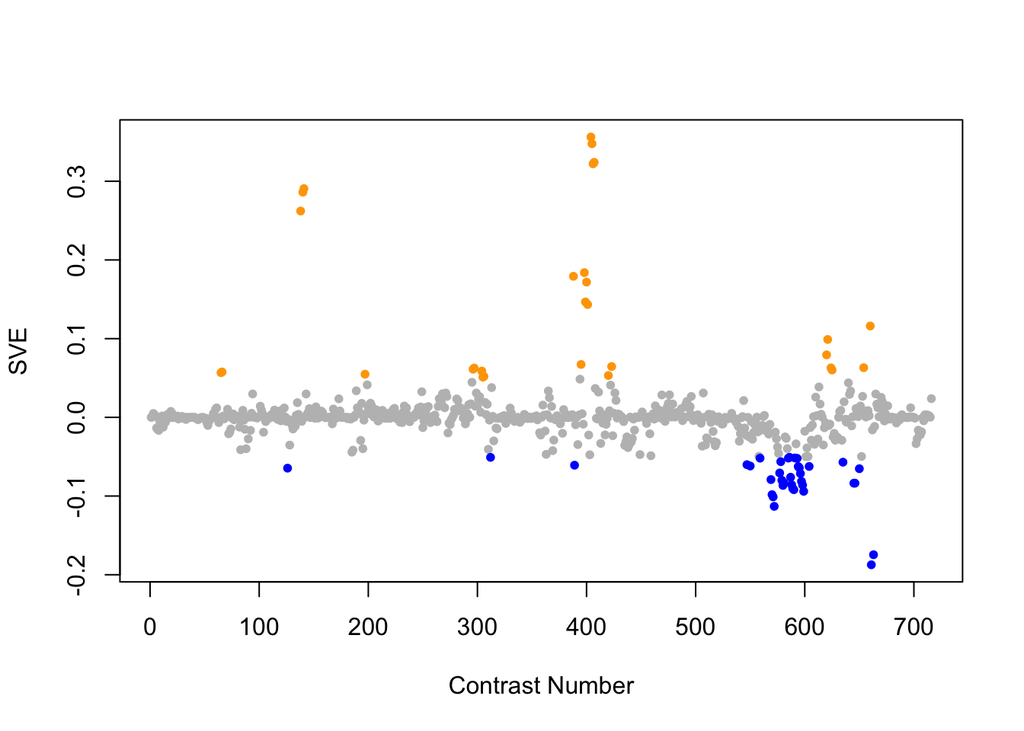

Positive SVE Contrasts:

|  | Contrast.Num | SVE | GEO.GSE | Cond.1 | Cond.2 | Mutation |
| --- | --- | --- | --- | --- | --- | --- |
| GSE30505.s2t1.vs.s4t1 | 404 | 0.36 | GSE30505 | L3 N2 (WT) ash-2 #1 | L3 glp-1 ash-2 #1 | glp-1 |
| GSE30505.s1t1.vs.s4t1 | 405 | 0.35 | GSE30505 | L3 N2 (WT) E.V. #1 | L3 glp-1 ash-2 #1 | glp-1 |
| GSE30505.s1t1.vs.s3t1 | 407 | 0.32 | GSE30505 | L3 N2 (WT) E.V. #1 | L3 glp-1 E.V. #1 | glp-1 |
| GSE30505.s2t1.vs.s3t1 | 406 | 0.32 | GSE30505 | L3 N2 (WT) ash-2 #1 | L3 glp-1 E.V. #1 | ash-2(RNAi) vs. glp-1 |
| GSE51691.s4t1.vs.s3t1 | 141 | 0.29 | GSE51691 | day8 hermaphrodite utx-1 RNAi +males rep 1 | day8 hermaphrodite utx-1 RNAi -males rep 1 |  |
| GSE51691.s4t1.vs.s2t1 | 140 | 0.29 | GSE51691 | day8 hermaphrodite utx-1 RNAi +males rep 1 | day8 hermaphrodite +males rep 1 | utx-1(RNAi) |
| GSE51691.s4t1.vs.s1t1 | 138 | 0.26 | GSE51691 | day8 hermaphrodite utx-1 RNAi +males rep 1 | day8 hermaphrodite -males rep 1 |  |
| GSE30505.s2t2.vs.s4t2 | 398 | 0.18 | GSE30505 | Day 8 N2 (WT) ash-2 #1 | Day 8 glp-1 ash-2 #1 | glp-1 |
| GSE32949.s1t1.vs.s0t1 | 388 | 0.18 | GSE32949 | C. elegans exposed to space condition, technical rep1 | C. elegans ground control, technical rep1 |  |
| GSE30505.s2t2.vs.s3t2 | 400 | 0.17 | GSE30505 | Day 8 N2 (WT) ash-2 #1 | Day 8 glp-1 E.V. #1 | ash-2(RNAi) vs. glp-1 |
| GSE30505.s1t2.vs.s4t2 | 399 | 0.15 | GSE30505 | Day 8 N2 (WT) E.V. #1 | Day 8 glp-1 ash-2 #1 | glp-1; ash-2 |
| GSE30505.s1t2.vs.s3t2 | 401 | 0.14 | GSE30505 | Day 8 N2 (WT) E.V. #1 | Day 8 glp-1 E.V. #1 | glp-1 |
| GSE15527.s2t1.vs.s1t1 | 660 | 0.12 | GSE15527 | sma-6 L4 worm, biological rep1 | dbl-1 L4 worm, biological rep1 | dbl-1 |
| GSE21376.s2t1.vs.s0t1 | 621 | 0.10 | GSE21376 | L1 larvae treated with mep-1(RNAi), replicate 1 | L1 larvae treated with gfp(RNAi), replicate 1 | mep-1 |
| GSE21376.s1t1.vs.s0t1 | 620 | 0.08 | GSE21376 | L1 larvae treated with let-418(RNAi), replicate 1 | L1 larvae treated with gfp(RNAi), replicate 1 | let-418 |
| GSE32339.s0t2.vs.s0t1 | 395 | 0.07 | GSE32339 | Adult Wild-type, biological rep1 | Larval Wild-type, biological rep1 |  |
| GSE28494.s0t2.vs.s0t1 | 423 | 0.06 | GSE28494 | wild-type N2 dissected germline 1 | wild-type N2 embryo 1 |  |
| GSE16405.s4t1.vs.s3t1 | 654 | 0.06 | GSE16405 | xpa-1_1 | nth-1;xpa-1_1 | nth-1 |
| GSE19972.s1t1.vs.s0t1 | 624 | 0.06 | GSE19972 | transgenic aex-3::his-SUMO-1 JS62_1 | control wild type N2_1 |  |
| GSE41366C.s0t6.vs.s0t1 | 297 | 0.06 | GSE41366 | control-continuous_expose-26h_harvest-rep1 | control-continuous_expose-0h_harvest-rep2 |  |
| GSE41366C.s0t5.vs.s0t1 | 296 | 0.06 | GSE41366 | control-continuous_expose-20h_harvest-rep1 | control-continuous_expose-0h_harvest-rep2 |  |
| GSE19972.s2t1.vs.s0t1 | 625 | 0.06 | GSE19972 | transgenic myo-4::his-SUMO-1 JS63_1 | control wild type N2_1 |  |
| GSE41366C.s1t3.vs.s1t1 | 304 | 0.06 | GSE41366 | low_DDVP-continuous_expose-14h_harvest-rep1 | low_DDVP-continuous_expose-2h_harvest-rep1 |  |
| GSE8659.s3t1.vs.s1t1 | 66 | 0.06 | GSE8659 | strain NL 2099 replicate 2 | N2 replicate 1 | rrf-3 |
| GSE8659.s2t1.vs.s1t1 | 65 | 0.06 | GSE8659 | strain GR1373 replicate 1 | N2 replicate 1 | eri-1 |
| GSE43959.s1t1.vs.s2t1 | 197 | 0.05 | GSE43959 | N2 young adult on E. coli OP50 rep 1 | N2 young adult on E. coli HT115 rep 1 |  |
| GSE28494.s1t1.vs.s0t1 | 420 | 0.05 | GSE28494 | lin-54(n2990) embryo 1 | wild-type N2 embryo 1 | lin-54 |
| GSE41366C.s1t5.vs.s1t1 | 306 | 0.05 | GSE41366 | low_DDVP-continuous_expose-26h_harvest-rep1 | low_DDVP-continuous_expose-2h_harvest-rep1 |  |
| GSE41366C.s1t4.vs.s1t1 | 305 | 0.05 | GSE41366 | low_DDVP-continuous_expose-20h_harvest-rep1 | low_DDVP-continuous_expose-2h_harvest-rep1 |  |

Negative SVE Contrasts:

|  | Contrast.Num | SVE | GEO.GSE | Cond.1 | Cond.2 | Mutation |
| --- | --- | --- | --- | --- | --- | --- |
| GSE15159.s1t1.vs.s0t1 | 661 | -0.19 | GSE15159 | glp-1_control_2007_rep1 | N2_control_2007_rep1 | glp-1 |
| GSE15159.s1t2.vs.s0t2 | 663 | -0.17 | GSE15159 | glp-1_UV_2007_rep1 | N2_UV_2007_rep1 | glp-1 |
| GSE2180.s1t10.vs.s1t1 | 572 | -0.11 | GSE2180 | 186-1 | 00B |  |
| GSE2180.s1t9.vs.s1t1 | 571 | -0.10 | GSE2180 | 143L | 00B |  |
| GSE2180.s1t8.vs.s1t1 | 570 | -0.10 | GSE2180 | 122-1 | 00B |  |
| GSE2180.s4t10.vs.s4t1 | 599 | -0.09 | GSE2180 | pp186-1 | pp0-1 |  |
| GSE2180.s3t10.vs.s3t1 | 590 | -0.09 | GSE2180 | p186-2 | p0-3 |  |
| GSE2180.s3t9.vs.s3t1 | 589 | -0.09 | GSE2180 | p143-2 | p0-3 |  |
| GSE2180.s2t9.vs.s2t1 | 580 | -0.09 | GSE2180 | ms143-2 | ms0-1 |  |
| GSE2180.s4t9.vs.s4t1 | 598 | -0.09 | GSE2180 | pp143-1 | pp0-1 |  |
| GSE2180.s3t8.vs.s3t1 | 588 | -0.09 | GSE2180 | p122-2 | p0-3 |  |
| GSE16915.s2t1.vs.s1t1 | 646 | -0.08 | GSE16915 | positive control (heat shock) | control sample |  |
| GSE16915.s2t1.vs.s3t1 | 645 | -0.08 | GSE16915 | positive control (heat shock) | bio-electrosprayed sample |  |
| GSE2180.s2t10.vs.s2t1 | 581 | -0.08 | GSE2180 | ms186-5 | ms0-1 |  |
| GSE2180.s4t8.vs.s4t1 | 597 | -0.08 | GSE2180 | pp122-1 | pp0-1 |  |
| GSE2180.s2t8.vs.s2t1 | 579 | -0.08 | GSE2180 | ms122-1 | ms0-1 |  |
| GSE2180.s1t7.vs.s1t1 | 569 | -0.08 | GSE2180 | 101G | 00B |  |
| GSE2180.s3t7.vs.s3t1 | 587 | -0.08 | GSE2180 | p101-2 | p0-3 |  |
| GSE2180.s4t7.vs.s4t1 | 596 | -0.07 | GSE2180 | pp101-1 | pp0-1 |  |
| GSE2180.s1t6.vs.s1t1 | 577 | -0.07 | GSE2180 | 83-1 | 00B |  |
| GSE16405.s3t1.vs.s1t1 | 650 | -0.07 | GSE16405 | nth-1;xpa-1_1 | N2_1 | nth-1;xpa-1 |
| GSE54011.s1t1.vs.s0t1 | 126 | -0.06 | GSE54011 | Ce 0.05 mM Se | Ce 0 mM Se |  |
| GSE2180.s3t6.vs.s3t1 | 595 | -0.06 | GSE2180 | p83-2 | p0-3 |  |
| GSE2180.s3t5.vs.s3t1 | 594 | -0.06 | GSE2180 | p66-1 | p0-3 |  |
| GSE2180.s4t6.vs.s4t1 | 604 | -0.06 | GSE2180 | pp83-1 | pp0-1 |  |
| GSE2180.s4t3.vs.s3t3 | 550 | -0.06 | GSE2180 | pp41-1 | p41-2 | pal-1(RNAi) |
| GSE32942.s2t1.vs.s1t1 | 389 | -0.06 | GSE32942 | WS5041 (mir 58(n4640); alg 1(tm492); opIs205). Replicate 1 | WS4303 (alg 1(tm492); opIs205). Replicate 1 | mir-58 |
| GSE2180.s4t3.vs.s1t3 | 547 | -0.06 | GSE2180 | pp41-1 | 41D | pie-1(zu154);pal-1(RNAi) |
| GSE18157.s1t1.vs.s0t1 | 635 | -0.06 | GSE18157 | Caenorhabditis elegans in biotin deficiency 1 | Caenorhabditis elegans grown with sufficient Biotin 1 |  |
| GSE2180.s2t7.vs.s2t1 | 578 | -0.06 | GSE2180 | ms101-2 | ms0-1 |  |
| GSE2180.s3t4.vs.s3t1 | 593 | -0.05 | GSE2180 | p53-2 | p0-3 |  |
| GSE2180.s4t5.vs.s1t5 | 559 | -0.05 | GSE2180 | pp66-1 | 66-4 | pie-1(zu154);pal-1(RNAi) |
| GSE2180.s2t5.vs.s2t1 | 585 | -0.05 | GSE2180 | ms66-3 | ms0-1 |  |
| GSE2180.s3t2.vs.s3t1 | 591 | -0.05 | GSE2180 | p23-2 | p0-3 |  |
| GSE41056.s1t2.vs.s1t1 | 312 | -0.05 | GSE41056 | JU1580_inf_1 | JU1580_1 |  |
| GSE2180.s2t6.vs.s2t1 | 586 | -0.05 | GSE2180 | ms83-5 | ms0-1 |  |

$~$

#### Contrast SVE, Up-Regulated Genes Only:

Calculating SVE for up-regulated and down-regulated genes separately may be more informative in many cases than projecting the up- and down- gene sets together. This is due to the fact that the weight distribution of many modules is highly skewed, indicating that only one of the hemi-modules may be biologically meaningful (i.e., a set of genes are strongly correlated by only a few genes (or none) are strongly anti-correlated to that set.)

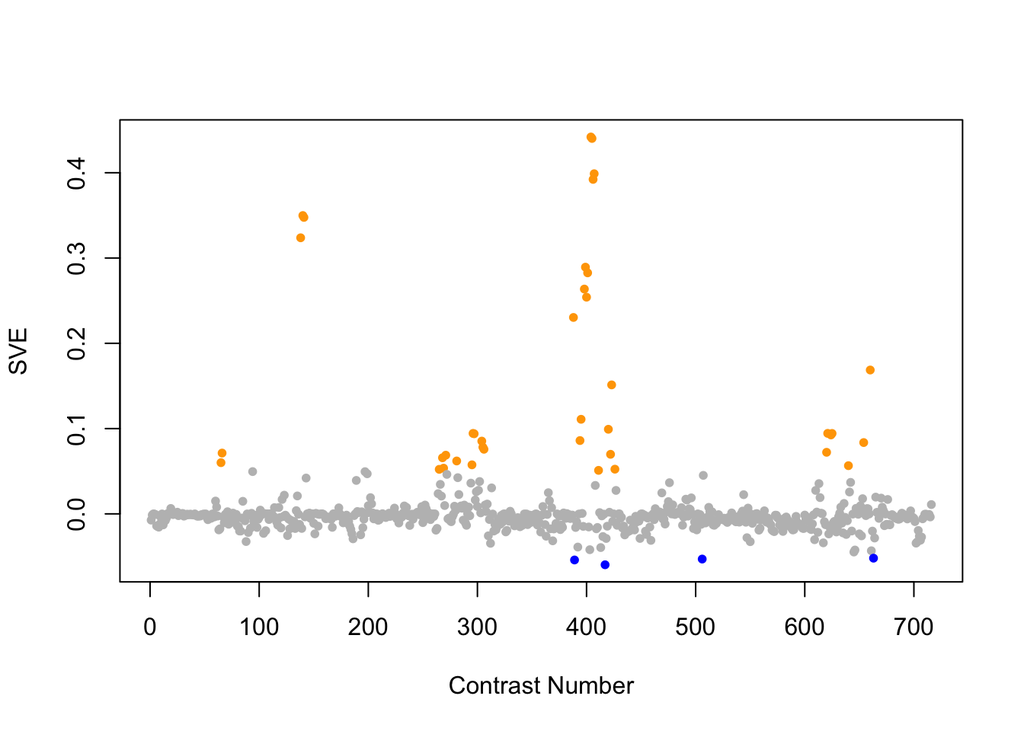

Positive SVE Contrasts:

|  | Contrast.Num | SVE | GEO.GSE | Cond.1 | Cond.2 | Mutation |
| --- | --- | --- | --- | --- | --- | --- |
| GSE30505.s2t1.vs.s4t1 | 404 | 0.44 | GSE30505 | L3 N2 (WT) ash-2 #1 | L3 glp-1 ash-2 #1 | glp-1 |
| GSE30505.s1t1.vs.s4t1 | 405 | 0.44 | GSE30505 | L3 N2 (WT) E.V. #1 | L3 glp-1 ash-2 #1 | glp-1 |
| GSE30505.s1t1.vs.s3t1 | 407 | 0.40 | GSE30505 | L3 N2 (WT) E.V. #1 | L3 glp-1 E.V. #1 | glp-1 |
| GSE30505.s2t1.vs.s3t1 | 406 | 0.39 | GSE30505 | L3 N2 (WT) ash-2 #1 | L3 glp-1 E.V. #1 | ash-2(RNAi) vs. glp-1 |
| GSE51691.s4t1.vs.s2t1 | 140 | 0.35 | GSE51691 | day8 hermaphrodite utx-1 RNAi +males rep 1 | day8 hermaphrodite +males rep 1 | utx-1(RNAi) |
| GSE51691.s4t1.vs.s3t1 | 141 | 0.35 | GSE51691 | day8 hermaphrodite utx-1 RNAi +males rep 1 | day8 hermaphrodite utx-1 RNAi -males rep 1 |  |
| GSE51691.s4t1.vs.s1t1 | 138 | 0.32 | GSE51691 | day8 hermaphrodite utx-1 RNAi +males rep 1 | day8 hermaphrodite -males rep 1 |  |
| GSE30505.s1t2.vs.s4t2 | 399 | 0.29 | GSE30505 | Day 8 N2 (WT) E.V. #1 | Day 8 glp-1 ash-2 #1 | glp-1; ash-2 |
| GSE30505.s1t2.vs.s3t2 | 401 | 0.28 | GSE30505 | Day 8 N2 (WT) E.V. #1 | Day 8 glp-1 E.V. #1 | glp-1 |
| GSE30505.s2t2.vs.s4t2 | 398 | 0.26 | GSE30505 | Day 8 N2 (WT) ash-2 #1 | Day 8 glp-1 ash-2 #1 | glp-1 |
| GSE30505.s2t2.vs.s3t2 | 400 | 0.25 | GSE30505 | Day 8 N2 (WT) ash-2 #1 | Day 8 glp-1 E.V. #1 | ash-2(RNAi) vs. glp-1 |
| GSE32949.s1t1.vs.s0t1 | 388 | 0.23 | GSE32949 | C. elegans exposed to space condition, technical rep1 | C. elegans ground control, technical rep1 |  |
| GSE15527.s2t1.vs.s1t1 | 660 | 0.17 | GSE15527 | sma-6 L4 worm, biological rep1 | dbl-1 L4 worm, biological rep1 | dbl-1 |
| GSE28494.s0t2.vs.s0t1 | 423 | 0.15 | GSE28494 | wild-type N2 dissected germline 1 | wild-type N2 embryo 1 |  |
| GSE32339.s0t2.vs.s0t1 | 395 | 0.11 | GSE32339 | Adult Wild-type, biological rep1 | Larval Wild-type, biological rep1 |  |
| GSE28494.s1t1.vs.s0t1 | 420 | 0.10 | GSE28494 | lin-54(n2990) embryo 1 | wild-type N2 embryo 1 | lin-54 |
| GSE21376.s2t1.vs.s0t1 | 621 | 0.09 | GSE21376 | L1 larvae treated with mep-1(RNAi), replicate 1 | L1 larvae treated with gfp(RNAi), replicate 1 | mep-1 |
| GSE41366C.s0t5.vs.s0t1 | 296 | 0.09 | GSE41366 | control-continuous_expose-20h_harvest-rep1 | control-continuous_expose-0h_harvest-rep2 |  |
| GSE19972.s2t1.vs.s0t1 | 625 | 0.09 | GSE19972 | transgenic myo-4::his-SUMO-1 JS63_1 | control wild type N2_1 |  |
| GSE41366C.s0t6.vs.s0t1 | 297 | 0.09 | GSE41366 | control-continuous_expose-26h_harvest-rep1 | control-continuous_expose-0h_harvest-rep2 |  |
| GSE19972.s1t1.vs.s0t1 | 624 | 0.09 | GSE19972 | transgenic aex-3::his-SUMO-1 JS62_1 | control wild type N2_1 |  |
| GSE32339.s1t2.vs.s1t1 | 394 | 0.09 | GSE32339 | Adult Mutant, biological rep1 | Larval Mutant, biological rep1 |  |
| GSE41366C.s1t3.vs.s1t1 | 304 | 0.09 | GSE41366 | low_DDVP-continuous_expose-14h_harvest-rep1 | low_DDVP-continuous_expose-2h_harvest-rep1 |  |
| GSE16405.s4t1.vs.s3t1 | 654 | 0.08 | GSE16405 | xpa-1_1 | nth-1;xpa-1_1 | nth-1 |
| GSE41366C.s1t4.vs.s1t1 | 305 | 0.08 | GSE41366 | low_DDVP-continuous_expose-20h_harvest-rep1 | low_DDVP-continuous_expose-2h_harvest-rep1 |  |
| GSE41366C.s1t5.vs.s1t1 | 306 | 0.08 | GSE41366 | low_DDVP-continuous_expose-26h_harvest-rep1 | low_DDVP-continuous_expose-2h_harvest-rep1 |  |
| GSE21376.s1t1.vs.s0t1 | 620 | 0.07 | GSE21376 | L1 larvae treated with let-418(RNAi), replicate 1 | L1 larvae treated with gfp(RNAi), replicate 1 | let-418 |
| GSE8659.s3t1.vs.s1t1 | 66 | 0.07 | GSE8659 | strain NL 2099 replicate 2 | N2 replicate 1 | rrf-3 |
| GSE28494.s1t2.vs.s1t1 | 422 | 0.07 | GSE28494 | lin-54(n3423) dissected germline 1 | lin-54(n2990) embryo 1 |  |
| GSE41366A.s1t3.vs.s1t1 | 271 | 0.07 | GSE41366 | low_DDVP-2h_expose-20h_harvest-rep1 | low_DDVP-2h_expose-8h_harvest-rep1 |  |
| GSE41366A.s2t3.vs.s2t1 | 268 | 0.07 | GSE41366 | high_DDVP-2h_expose-20h_harvest-rep1 | high_DDVP-2h_expose-8h_harvest-rep1 |  |
| GSE41366B.s2t2.vs.s2t1 | 281 | 0.06 | GSE41366 | high_DDVP-8h_expose-20h_harvest-rep1 | high_DDVP-8h_expose-14h_harvest-rep1 |  |
| GSE8659.s2t1.vs.s1t1 | 65 | 0.06 | GSE8659 | strain GR1373 replicate 1 | N2 replicate 1 | eri-1 |
| GSE41366C.s0t4.vs.s0t1 | 295 | 0.06 | GSE41366 | control-continuous_expose-14h_harvest-rep1 | control-continuous_expose-0h_harvest-rep2 |  |
| GSE18132.s2t2.vs.s2t1 | 640 | 0.06 | GSE18132 | Oga Fed L4, biological replicate 1 | Oga starved L1, biological replicate 1 |  |
| GSE41366A.s2t4.vs.s2t1 | 269 | 0.05 | GSE41366 | high_DDVP-2h_expose-26h_harvest-rep1 | high_DDVP-2h_expose-8h_harvest-rep1 |  |
| GSE27677A.s2t2.vs.s0t2 | 426 | 0.05 | GSE27677 | jun-1, Fast , rep 1 | N2, Fast , rep 1 | 40694 |
| GSE41366A.s0t3.vs.s0t1 | 265 | 0.05 | GSE41366 | control-2h_expose-20h_harvest-rep1 | control-2h_expose-8h_harvest-rep1 |  |
| GSE30505.s2t2.vs.s2t1 | 411 | 0.05 | GSE30505 | Day 8 N2 (WT) ash-2 #1 | L3 N2 (WT) ash-2 #1 |  |

Negative SVE Contrasts:

|  | Contrast.Num | SVE | GEO.GSE | Cond.1 | Cond.2 | Mutation |
| --- | --- | --- | --- | --- | --- | --- |
| GSE28856.s0t2.vs.s0t1 | 417 | -0.06 | GSE28856 | Wild-type 1 h after shifting temperature rep1 | Wild-type 0 h after shifting temperature rep1 |  |
| GSE32942.s2t1.vs.s1t1 | 389 | -0.05 | GSE32942 | WS5041 (mir 58(n4640); alg 1(tm492); opIs205). Replicate 1 | WS4303 (alg 1(tm492); opIs205). Replicate 1 | mir-58 |
| GSE2210.s1t1.vs.s0t1 | 506 | -0.05 | GSE2210 | tom-1(nu468) Sample 1 | Wild type Sample 1 | tom-1 |
| GSE15159.s1t2.vs.s0t2 | 663 | -0.05 | GSE15159 | glp-1_UV_2007_rep1 | N2_UV_2007_rep1 | glp-1 |
| GSE16915.s2t1.vs.s3t1 | 645 | -0.04 | GSE16915 | positive control (heat shock) | bio-electrosprayed sample |  |

$~$

#### Contrast SVE, Down-Regulated Genes Only:

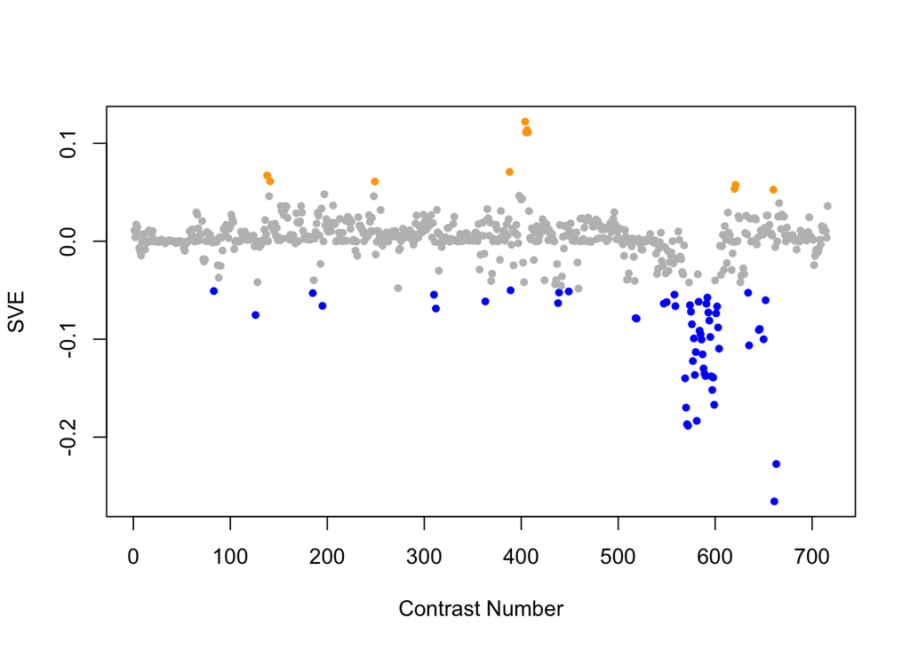

Positive SVE Contrasts:

|  | Contrast.Num | SVE | GEO.GSE | Cond.1 | Cond.2 | Mutation |
| --- | --- | --- | --- | --- | --- | --- |
| GSE30505.s2t1.vs.s4t1 | 404 | 0.12 | GSE30505 | L3 N2 (WT) ash-2 #1 | L3 glp-1 ash-2 #1 | glp-1 |
| GSE30505.s2t1.vs.s3t1 | 406 | 0.11 | GSE30505 | L3 N2 (WT) ash-2 #1 | L3 glp-1 E.V. #1 | ash-2(RNAi) vs. glp-1 |
| GSE30505.s1t1.vs.s3t1 | 407 | 0.11 | GSE30505 | L3 N2 (WT) E.V. #1 | L3 glp-1 E.V. #1 | glp-1 |
| GSE30505.s1t1.vs.s4t1 | 405 | 0.11 | GSE30505 | L3 N2 (WT) E.V. #1 | L3 glp-1 ash-2 #1 | glp-1 |
| GSE32949.s1t1.vs.s0t1 | 388 | 0.07 | GSE32949 | C. elegans exposed to space condition, technical rep1 | C. elegans ground control, technical rep1 |  |
| GSE51691.s4t1.vs.s1t1 | 138 | 0.07 | GSE51691 | day8 hermaphrodite utx-1 RNAi +males rep 1 | day8 hermaphrodite -males rep 1 |  |
| GSE51691.s4t1.vs.s3t1 | 141 | 0.06 | GSE51691 | day8 hermaphrodite utx-1 RNAi +males rep 1 | day8 hermaphrodite utx-1 RNAi -males rep 1 |  |
| GSE42192.s2t2.vs.s0t2 | 249 | 0.06 | GSE42192 | C.elegans fed with CNCM I-4317 10 days rep1 | C.elegans fed with E.coli OP50 10 days rep1 |  |
| GSE21376.s2t1.vs.s0t1 | 621 | 0.06 | GSE21376 | L1 larvae treated with mep-1(RNAi), replicate 1 | L1 larvae treated with gfp(RNAi), replicate 1 | mep-1 |
| GSE21376.s1t1.vs.s0t1 | 620 | 0.05 | GSE21376 | L1 larvae treated with let-418(RNAi), replicate 1 | L1 larvae treated with gfp(RNAi), replicate 1 | let-418 |
| GSE15527.s2t1.vs.s1t1 | 660 | 0.05 | GSE15527 | sma-6 L4 worm, biological rep1 | dbl-1 L4 worm, biological rep1 | dbl-1 |

Negative SVE Contrasts:

|  | Contrast.Num | SVE | GEO.GSE | Cond.1 | Cond.2 | Mutation |
| --- | --- | --- | --- | --- | --- | --- |
| GSE15159.s1t1.vs.s0t1 | 661 | -0.27 | GSE15159 | glp-1_control_2007_rep1 | N2_control_2007_rep1 | glp-1 |
| GSE15159.s1t2.vs.s0t2 | 663 | -0.23 | GSE15159 | glp-1_UV_2007_rep1 | N2_UV_2007_rep1 | glp-1 |
| GSE2180.s1t10.vs.s1t1 | 572 | -0.19 | GSE2180 | 186-1 | 00B |  |
| GSE2180.s1t9.vs.s1t1 | 571 | -0.19 | GSE2180 | 143L | 00B |  |
| GSE2180.s2t10.vs.s2t1 | 581 | -0.18 | GSE2180 | ms186-5 | ms0-1 |  |
| GSE2180.s1t8.vs.s1t1 | 570 | -0.17 | GSE2180 | 122-1 | 00B |  |
| GSE2180.s4t10.vs.s4t1 | 599 | -0.17 | GSE2180 | pp186-1 | pp0-1 |  |
| GSE2180.s4t8.vs.s4t1 | 597 | -0.15 | GSE2180 | pp122-1 | pp0-1 |  |
| GSE2180.s1t7.vs.s1t1 | 569 | -0.14 | GSE2180 | 101G | 00B |  |
| GSE2180.s4t9.vs.s4t1 | 598 | -0.14 | GSE2180 | pp143-1 | pp0-1 |  |
| GSE2180.s4t7.vs.s4t1 | 596 | -0.14 | GSE2180 | pp101-1 | pp0-1 |  |
| GSE2180.s3t10.vs.s3t1 | 590 | -0.14 | GSE2180 | p186-2 | p0-3 |  |
| GSE2180.s2t8.vs.s2t1 | 579 | -0.14 | GSE2180 | ms122-1 | ms0-1 |  |
| GSE2180.s3t9.vs.s3t1 | 589 | -0.14 | GSE2180 | p143-2 | p0-3 |  |
| GSE2180.s3t8.vs.s3t1 | 588 | -0.13 | GSE2180 | p122-2 | p0-3 |  |
| GSE2180.s1t6.vs.s1t1 | 577 | -0.12 | GSE2180 | 83-1 | 00B |  |
| GSE2180.s3t7.vs.s3t1 | 587 | -0.12 | GSE2180 | p101-2 | p0-3 |  |
| GSE2180.s2t9.vs.s2t1 | 580 | -0.11 | GSE2180 | ms143-2 | ms0-1 |  |
| GSE2180.s4t6.vs.s4t1 | 604 | -0.11 | GSE2180 | pp83-1 | pp0-1 |  |
| GSE18157.s1t1.vs.s0t1 | 635 | -0.11 | GSE18157 | Caenorhabditis elegans in biotin deficiency 1 | Caenorhabditis elegans grown with sufficient Biotin 1 |  |
| GSE2180.s2t6.vs.s2t1 | 586 | -0.10 | GSE2180 | ms83-5 | ms0-1 |  |
| GSE16405.s3t1.vs.s1t1 | 650 | -0.10 | GSE16405 | nth-1;xpa-1_1 | N2_1 | nth-1;xpa-1 |
| GSE2180.s2t7.vs.s2t1 | 578 | -0.10 | GSE2180 | ms101-2 | ms0-1 |  |
| GSE2180.s3t6.vs.s3t1 | 595 | -0.10 | GSE2180 | p83-2 | p0-3 |  |
| GSE2180.s2t5.vs.s2t1 | 585 | -0.09 | GSE2180 | ms66-3 | ms0-1 |  |
| GSE2180.s2t4.vs.s2t1 | 584 | -0.09 | GSE2180 | ms53-4 | ms0-1 |  |
| GSE16915.s2t1.vs.s3t1 | 645 | -0.09 | GSE16915 | positive control (heat shock) | bio-electrosprayed sample |  |
| GSE16915.s2t1.vs.s1t1 | 646 | -0.09 | GSE16915 | positive control (heat shock) | control sample |  |
| GSE2180.s4t5.vs.s4t1 | 603 | -0.09 | GSE2180 | pp66-1 | pp0-1 |  |
| GSE2180.s1t5.vs.s1t1 | 576 | -0.08 | GSE2180 | 66-4 | 00B |  |
| GSE2180.s3t5.vs.s3t1 | 594 | -0.08 | GSE2180 | p66-1 | p0-3 |  |
| GSE2180.s4t7.vs.s2t7 | 519 | -0.08 | GSE2180 | pp101-1 | ms101-2 |  |
| GSE2180.s3t7.vs.s2t7 | 518 | -0.08 | GSE2180 | p101-2 | ms101-2 |  |
| GSE54011.s1t1.vs.s0t1 | 126 | -0.08 | GSE54011 | Ce 0.05 mM Se | Ce 0 mM Se |  |
| GSE2180.s4t3.vs.s4t1 | 601 | -0.07 | GSE2180 | pp41-1 | pp0-1 |  |
| GSE2180.s3t4.vs.s3t1 | 593 | -0.07 | GSE2180 | p53-2 | p0-3 |  |
| GSE2180.s1t4.vs.s1t1 | 575 | -0.07 | GSE2180 | 53-1 | 00B |  |
| GSE41056.s1t2.vs.s1t1 | 312 | -0.07 | GSE41056 | JU1580_inf_1 | JU1580_1 |  |
| GSE2180.s4t4.vs.s4t1 | 602 | -0.07 | GSE2180 | pp53-1 | pp0-1 |  |
| GSE2180.s4t5.vs.s1t5 | 559 | -0.07 | GSE2180 | pp66-1 | 66-4 | pie-1(zu154);pal-1(RNAi) |
| GSE43959.s2t1.vs.s3t1 | 195 | -0.07 | GSE43959 | N2 young adult on E. coli HT115 rep 1 | N2 young adult on Comamonas DA1877 rep 1 |  |
| GSE2180.s1t3.vs.s1t1 | 574 | -0.07 | GSE2180 | 41D | 00B |  |
| GSE2180.s3t2.vs.s3t1 | 591 | -0.06 | GSE2180 | p23-2 | p0-3 |  |
| GSE2180.s4t3.vs.s1t3 | 547 | -0.06 | GSE2180 | pp41-1 | 41D | pie-1(zu154);pal-1(RNAi) |
| GSE27677B.s1t6.vs.s1t1 | 438 | -0.06 | GSE27677 | N2, Fast 18 h, rep 1 | N2, Fed 0 h, rep 1 |  |
| GSE2180.s4t3.vs.s3t3 | 550 | -0.06 | GSE2180 | pp41-1 | p41-2 | pal-1(RNAi) |
| GSE2180.s2t3.vs.s2t1 | 583 | -0.06 | GSE2180 | ms41-1 | ms0-1 |  |
| GSE36358.s2t1.vs.s0t1 | 363 | -0.06 | GSE36358 | Clino Rotation | Ground Control (Tsukuba space center) |  |
| GSE16405.s3t1.vs.s2t1 | 652 | -0.06 | GSE16405 | nth-1;xpa-1_1 | nth-1_1 | xpa-1 |
| GSE2180.s3t3.vs.s3t1 | 592 | -0.06 | GSE2180 | p41-2 | p0-3 |  |
| GSE41056.s1t2.vs.s0t2 | 310 | -0.05 | GSE41056 | JU1580_inf_1 | N2_inf_1 |  |
| GSE2180.s3t5.vs.s1t5 | 558 | -0.05 | GSE2180 | p66-1 | 66-4 | pie-1(zu154) |
| GSE4766.s1t3.vs.s1t1 | 185 | -0.05 | GSE4766 | Pooled glp-1 C elegans old adults_rep1 | Pooled glp-1 C elegans embryos_bleach NaOH prep_rep1 |  |
| GSE19138.s1t1.vs.s0t1 | 634 | -0.05 | GSE19138 | ALG-1(-) 1 | WT1 | alg-1 |
| GSE27677B.s1t7.vs.s1t1 | 439 | -0.05 | GSE27677 | N2, Fast 24 h, rep 1 | N2, Fed 0 h, rep 1 |  |
| GSE25831.s1t1.vs.s2t1 | 449 | -0.05 | GSE25831 | WT_fedL1_rep1 | mixed embryo XX_WT-N_080307_A |  |
| GSE6563.s1t1.vs.s0t1 | 83 | -0.05 | GSE6563 | daf19(m86)_daf12(sa204) replicate 1 | daf19(WT)_daf12(sa204) replicate 1 | daf-19 |
| GSE32942.s2t1.vs.s1t1 | 389 | -0.05 | GSE32942 | WS5041 (mir 58(n4640); alg 1(tm492); opIs205). Replicate 1 | WS4303 (alg 1(tm492); opIs205). Replicate 1 | mir-58 |

$~$

$~$

#### GO Term Enrichment:

This analysis tests each hemi-module for enrichment of specific GO terms. Only gene-level annotations (e.g., as would be found on the gene’s page in Wormbase) are tested - the hierarchical structure of the GO ontology is not taken into account.

*Note: At least the top two most enriched terms from each GO domain (BP/MF/CC) are shown, even when not statistically significant.*

##### Enriched GO terms: Hemi-module A

| ID | GO.Term | GO Domain | Raw p-value | Adj p-value |
| --- | --- | --- | --- | --- |
| [GO_0006417](http://amigo.geneontology.org/amigo/term/GO:0006417) | regulation of translation | BP | 5.51e-10 | 2.01e-06 |
| [GO_0007129](http://amigo.geneontology.org/amigo/term/GO:0007129) | synapsis | BP | 6.29e-09 | 7.64e-06 |
| [GO_0007130](http://amigo.geneontology.org/amigo/term/GO:0007130) | synaptonemal complex assembly | BP | 6.29e-09 | 7.64e-06 |
| [GO_0007283](http://amigo.geneontology.org/amigo/term/GO:0007283) | spermatogenesis | BP | 8.69e-09 | 7.92e-06 |
| [GO_0045132](http://amigo.geneontology.org/amigo/term/GO:0045132) | meiotic chromosome segregation | BP | 7.23e-08 | 5.27e-05 |
| [GO_0031047](http://amigo.geneontology.org/amigo/term/GO:0031047) | gene silencing by RNA | BP | 3.04e-07 | 1.72e-04 |
| [GO_0030997](http://amigo.geneontology.org/amigo/term/GO:0030997) | regulation of centriole-centriole cohesion | BP | 3.30e-07 | 1.72e-04 |
| [GO_0007276](http://amigo.geneontology.org/amigo/term/GO:0007276) | gamete generation | BP | 3.82e-07 | 1.74e-04 |
| [GO_0051321](http://amigo.geneontology.org/amigo/term/GO:0051321) | meiotic cell cycle | BP | 6.82e-07 | 2.76e-04 |
| [GO_0042138](http://amigo.geneontology.org/amigo/term/GO:0042138) | meiotic DNA double-strand break formation | BP | 1.66e-05 | 5.49e-03 |
| [GO_2000766](http://amigo.geneontology.org/amigo/term/GO:2000766) | negative regulation of cytoplasmic translation | BP | 1.66e-05 | 5.49e-03 |
| [GO_0007131](http://amigo.geneontology.org/amigo/term/GO:0007131) | reciprocal meiotic recombination | BP | 2.02e-05 | 5.66e-03 |
| [GO_0016925](http://amigo.geneontology.org/amigo/term/GO:0016925) | protein sumoylation | BP | 2.02e-05 | 5.66e-03 |
| [GO_0017148](http://amigo.geneontology.org/amigo/term/GO:0017148) | negative regulation of translation | BP | 2.82e-05 | 7.33e-03 |
| [GO_0048477](http://amigo.geneontology.org/amigo/term/GO:0048477) | oogenesis | BP | 5.41e-05 | 1.32e-02 |
| [GO_0007062](http://amigo.geneontology.org/amigo/term/GO:0007062) | sister chromatid cohesion | BP | 1.40e-04 | 3.18e-02 |
| [GO_0007186](http://amigo.geneontology.org/amigo/term/GO:0007186) | G protein-coupled receptor signaling pathway | BP | 2.59e-04 | 5.29e-02 |
| [GO_0010845](http://amigo.geneontology.org/amigo/term/GO:0010845) | positive regulation of reciprocal meiotic recombination | BP | 2.61e-04 | 5.29e-02 |
| [GO_0030154](http://amigo.geneontology.org/amigo/term/GO:0030154) | cell differentiation | BP | 2.84e-04 | 5.44e-02 |
| [GO_0007275](http://amigo.geneontology.org/amigo/term/GO:0007275) | multicellular organism development | BP | 4.43e-04 | 7.66e-02 |
| [GO_0032465](http://amigo.geneontology.org/amigo/term/GO:0032465) | regulation of cytokinesis | BP | 4.63e-04 | 7.66e-02 |
| [GO_0045910](http://amigo.geneontology.org/amigo/term/GO:0045910) | negative regulation of DNA recombination | BP | 4.63e-04 | 7.66e-02 |
| [GO_0042078](http://amigo.geneontology.org/amigo/term/GO:0042078) | germ-line stem cell division | BP | 6.28e-04 | 9.95e-02 |
| [GO_0003723](http://amigo.geneontology.org/amigo/term/GO:0003723) | RNA binding | MF | 1.04e-15 | 2.12e-12 |
| [GO_0003676](http://amigo.geneontology.org/amigo/term/GO:0003676) | nucleic acid binding | MF | 5.13e-13 | 5.24e-10 |
| [GO_0003730](http://amigo.geneontology.org/amigo/term/GO:0003730) | mRNA 3’-UTR binding | MF | 4.14e-09 | 2.82e-06 |
| [GO_0005515](http://amigo.geneontology.org/amigo/term/GO:0005515) | protein binding | MF | 1.17e-07 | 5.96e-05 |
| [GO_0019789](http://amigo.geneontology.org/amigo/term/GO:0019789) | SUMO transferase activity | MF | 2.25e-06 | 9.21e-04 |
| [GO_0008135](http://amigo.geneontology.org/amigo/term/GO:0008135) | translation factor activity, RNA binding | MF | 4.09e-05 | 1.19e-02 |
| [GO_0008432](http://amigo.geneontology.org/amigo/term/GO:0008432) | JUN kinase binding | MF | 4.09e-05 | 1.19e-02 |
| [GO_0045182](http://amigo.geneontology.org/amigo/term/GO:0045182) | translation regulator activity | MF | 8.09e-05 | 2.07e-02 |
| [GO_0000900](http://amigo.geneontology.org/amigo/term/GO:0000900) | translation repressor activity, mRNA regulatory element binding | MF | 1.40e-04 | 2.98e-02 |
| [GO_0003729](http://amigo.geneontology.org/amigo/term/GO:0003729) | mRNA binding | MF | 1.46e-04 | 2.98e-02 |
| [GO_0043022](http://amigo.geneontology.org/amigo/term/GO:0043022) | ribosome binding | MF | 1.71e-04 | 3.18e-02 |
| [GO_0046589](http://amigo.geneontology.org/amigo/term/GO:0046589) | ribonuclease T1 activity | MF | 2.61e-04 | 4.45e-02 |
| [GO_0043186](http://amigo.geneontology.org/amigo/term/GO:0043186) | P granule | CC | 1.74e-20 | 1.61e-17 |
| [GO_0000795](http://amigo.geneontology.org/amigo/term/GO:0000795) | synaptonemal complex | CC | 9.24e-12 | 4.29e-09 |
| [GO_0000800](http://amigo.geneontology.org/amigo/term/GO:0000800) | lateral element | CC | 1.06e-09 | 2.39e-07 |
| [GO_0016020](http://amigo.geneontology.org/amigo/term/GO:0016020) | membrane | CC | 1.11e-09 | 2.39e-07 |
| [GO_0000794](http://amigo.geneontology.org/amigo/term/GO:0000794) | condensed nuclear chromosome | CC | 1.30e-09 | 2.39e-07 |
| [GO_0016021](http://amigo.geneontology.org/amigo/term/GO:0016021) | integral component of membrane | CC | 1.54e-09 | 2.39e-07 |
| [GO_0000801](http://amigo.geneontology.org/amigo/term/GO:0000801) | central element | CC | 6.69e-08 | 8.87e-06 |
| [GO_0005694](http://amigo.geneontology.org/amigo/term/GO:0005694) | chromosome | CC | 1.27e-06 | 1.47e-04 |
| [GO_0005634](http://amigo.geneontology.org/amigo/term/GO:0005634) | nucleus | CC | 6.38e-06 | 6.58e-04 |
| [GO_0034399](http://amigo.geneontology.org/amigo/term/GO:0034399) | nuclear periphery | CC | 7.91e-06 | 7.34e-04 |
| [GO_0048471](http://amigo.geneontology.org/amigo/term/GO:0048471) | perinuclear region of cytoplasm | CC | 4.41e-05 | 3.72e-03 |
| [GO_0000793](http://amigo.geneontology.org/amigo/term/GO:0000793) | condensed chromosome | CC | 5.41e-05 | 4.19e-03 |
| [GO_1990124](http://amigo.geneontology.org/amigo/term/GO:1990124) | messenger ribonucleoprotein complex | CC | 3.28e-04 | 2.34e-02 |
| [GO_0000922](http://amigo.geneontology.org/amigo/term/GO:0000922) | spindle pole | CC | 5.51e-04 | 3.65e-02 |
| [GO_0043073](http://amigo.geneontology.org/amigo/term/GO:0043073) | germ cell nucleus | CC | 6.28e-04 | 3.89e-02 |
| [GO_0005737](http://amigo.geneontology.org/amigo/term/GO:0005737) | cytoplasm | CC | 9.14e-04 | 5.30e-02 |
| [GO_0019185](http://amigo.geneontology.org/amigo/term/GO:0019185) | snRNA-activating protein complex | CC | 1.53e-03 | 8.38e-02 |

##### Enriched GO terms: Hemi-module B

| ID | GO.Term | GO Domain | Raw p-value | Adj p-value |
| --- | --- | --- | --- | --- |
| [GO_1901407](http://amigo.geneontology.org/amigo/term/GO:1901407) | regulation of phosphorylation of RNA polymerase II C-terminal domain | BP | 1.99e-03 | 1.00e+00 |
| [GO_0032786](http://amigo.geneontology.org/amigo/term/GO:0032786) | positive regulation of DNA-templated transcription, elongation | BP | 2.99e-03 | 1.00e+00 |
| [GO_0097027](http://amigo.geneontology.org/amigo/term/GO:0097027) | ubiquitin-protein transferase activator activity | MF | 1.50e-03 | 1.00e+00 |
| [GO_0019239](http://amigo.geneontology.org/amigo/term/GO:0019239) | deaminase activity | MF | 1.99e-03 | 1.00e+00 |
| [GO_0000839](http://amigo.geneontology.org/amigo/term/GO:0000839) | Hrd1p ubiquitin ligase ERAD-L complex | CC | 1.99e-03 | 1.00e+00 |
| [GO_0008024](http://amigo.geneontology.org/amigo/term/GO:0008024) | cyclin/CDK positive transcription elongation factor complex | CC | 2.49e-03 | 1.00e+00 |

$~$

$~$

#### Tissue Enrichment:

This analysis tests each hemi-module for enrichment of genes associated with anatomy terms. Negative enrichment scores indicate fewer hemi-module genes than expected by random chance were associated with the anatomy term in question.

##### Enriched tissues: Hemi-module A

| ID | Anatomy.Term | Definition | Raw p-value | Adj p-value |
| --- | --- | --- | --- | --- |
| [WBbt_0005784](https://wormbase.org/species/all/anatomy_term/WBbt:0005784) | germ line | cell line which early in development becomes differentiated from the remaining somatic cell line, and alone has the potential to undergo meiosis and form gametes. | 1.66e-44 | 4.03e-41 |
| [WBbt_0004575](https://wormbase.org/species/all/anatomy_term/WBbt:0004575) | Z3 | Germ line precursor cell | 1.32e-16 | 1.07e-13 |
| [WBbt_0004576](https://wormbase.org/species/all/anatomy_term/WBbt:0004576) | Z2 | Germ line precursor cell | 1.32e-16 | 1.07e-13 |
| [WBbt_0006796](https://wormbase.org/species/all/anatomy_term/WBbt:0006796) | germ cell | a cell, of either sex, directly concerned in the production of a new organism. | 1.76e-10 | 1.07e-07 |
| [WBbt_0005175](https://wormbase.org/species/all/anatomy_term/WBbt:0005175) | gonad | organ producing either sperm or ova. | 9.45e-08 | 4.60e-05 |
| [WBbt_0006874](https://wormbase.org/species/all/anatomy_term/WBbt:0006874) | Psub1 | embryonic founder cell | 2.73e-06 | 1.11e-03 |
| [WBbt_0006799](https://wormbase.org/species/all/anatomy_term/WBbt:0006799) | spermatocyte | A cell which gives rise to spermatids by meiosis. | 3.33e-06 | 1.16e-03 |
| [WBbt_0004421](https://wormbase.org/species/all/anatomy_term/WBbt:0004421) | Psub4 | Embryonic founder cell of germ line | 4.37e-06 | 1.33e-03 |
| [WBbt_0006875](https://wormbase.org/species/all/anatomy_term/WBbt:0006875) | Psub3 | embryonic founder cell | 1.43e-05 | 3.86e-03 |
| [WBbt_0006873](https://wormbase.org/species/all/anatomy_term/WBbt:0006873) | Psub2 | embryonic founder cell | 1.76e-05 | 4.27e-03 |
| [WBbt_0006798](https://wormbase.org/species/all/anatomy_term/WBbt:0006798) | sperm | Male haploid germ cell. | 1.45e-04 | 2.64e-02 |
| [WBbt_0006797](https://wormbase.org/species/all/anatomy_term/WBbt:0006797) | oocyte | a female haploid germ cell. | 1.49e-04 | 2.64e-02 |
| [WBbt_0005906](https://wormbase.org/species/all/anatomy_term/WBbt:0005906) | ABa | embryonic cell | 1.63e-04 | 2.64e-02 |
| [WBbt_0005994](https://wormbase.org/species/all/anatomy_term/WBbt:0005994) | ABp | embryonic cell | 1.63e-04 | 2.64e-02 |
| [WBbt_0006876](https://wormbase.org/species/all/anatomy_term/WBbt:0006876) | EMS | embryonic cell | 1.63e-04 | 2.64e-02 |

##### Enriched tissues: Hemi-module B

No significant annotations.

$~$

$~$

#### HOMER promoter motif enrichment:

This analysis tests each hemi-module for enrichment of 108 known *C. elegans* transcription factor binding site motifs (see [108 CE motifs](https://katiepod.github.io//all.worm.motifs.html)) using the HOMER (Hypergeometric Optimization of Motif EnRichment) software (see [PMID:20513432](https://pubmed.ncbi.nlm.nih.gov/20513432)). HOMER was run using default parameters on sequences 1 kb upstream of the transcription start site.

##### Motif enrichment: Hemi-module A

Total target sequences = 305  
Total background sequences = 36763  
* - possible false positive

Rank

Motif

P-value

log P-pvalue

% of Targets

% of Background

STD(Bg STD)

Best Match/Details

Motif File

1

[figure not shown]

1e-58

-1.349e+02

50.49%

12.07%

228.9bp (316.5bp)

SD0001.1_at_AC_acceptor/Jaspar(0.520)  
[More Information](https://katiepod.github.io/HomerResults/m38_a_hemi_genes.txt.out.1kb/homerResults/motif1.info.html) | [Similar Motifs Found](https://katiepod.github.io/HomerResults/m38_a_hemi_genes.txt.out.1kb/homerResults/motif1.similar.html)

[motif file (matrix)](https://katiepod.github.io/HomerResults/m38_a_hemi_genes.txt.out.1kb/homerResults/motif1.motif)

2

[figure not shown]

1e-50

-1.156e+02

37.05%

6.92%

216.9bp (347.2bp)

POL011.1_XCPE1/Jaspar(0.592)  
[More Information](https://katiepod.github.io/HomerResults/m38_a_hemi_genes.txt.out.1kb/homerResults/motif2.info.html) | [Similar Motifs Found](https://katiepod.github.io/HomerResults/m38_a_hemi_genes.txt.out.1kb/homerResults/motif2.similar.html)

[motif file (matrix)](https://katiepod.github.io/HomerResults/m38_a_hemi_genes.txt.out.1kb/homerResults/motif2.motif)

3

[figure not shown]

1e-36

-8.460e+01

32.79%

7.42%

208.7bp (339.2bp)

POL006.1_BREu/Jaspar(0.567)  
[More Information](https://katiepod.github.io/HomerResults/m38_a_hemi_genes.txt.out.1kb/homerResults/motif3.info.html) | [Similar Motifs Found](https://katiepod.github.io/HomerResults/m38_a_hemi_genes.txt.out.1kb/homerResults/motif3.similar.html)

[motif file (matrix)](https://katiepod.github.io/HomerResults/m38_a_hemi_genes.txt.out.1kb/homerResults/motif3.motif)

4

[figure not shown]

1e-15

-3.571e+01

12.13%

2.25%

234.4bp (353.6bp)

EFL-1(E2F)/cElegans-L1-EFL1-ChIP-Seq(modEncode)/Homer(0.544)  
[More Information](https://katiepod.github.io/HomerResults/m38_a_hemi_genes.txt.out.1kb/homerResults/motif4.info.html) | [Similar Motifs Found](https://katiepod.github.io/HomerResults/m38_a_hemi_genes.txt.out.1kb/homerResults/motif4.similar.html)

[motif file (matrix)](https://katiepod.github.io/HomerResults/m38_a_hemi_genes.txt.out.1kb/homerResults/motif4.motif)

5

[figure not shown]

1e-13

-3.203e+01

15.41%

4.09%

258.9bp (342.3bp)

EGL-5(Homeobox)/cElegans-L3-EGL5-ChIP-Seq(modEncode)/Homer(0.584)  
[More Information](https://katiepod.github.io/HomerResults/m38_a_hemi_genes.txt.out.1kb/homerResults/motif5.info.html) | [Similar Motifs Found](https://katiepod.github.io/HomerResults/m38_a_hemi_genes.txt.out.1kb/homerResults/motif5.similar.html)

[motif file (matrix)](https://katiepod.github.io/HomerResults/m38_a_hemi_genes.txt.out.1kb/homerResults/motif5.motif)

6

[figure not shown]

1e-13

-3.048e+01

18.69%

6.07%

261.3bp (349.8bp)

PHA-4(Forkhead)/cElegans-Embryos-PHA4-ChIP-Seq(modEncode)/Homer(0.841)  
[More Information](https://katiepod.github.io/HomerResults/m38_a_hemi_genes.txt.out.1kb/homerResults/motif6.info.html) | [Similar Motifs Found](https://katiepod.github.io/HomerResults/m38_a_hemi_genes.txt.out.1kb/homerResults/motif6.similar.html)

[motif file (matrix)](https://katiepod.github.io/HomerResults/m38_a_hemi_genes.txt.out.1kb/homerResults/motif6.motif)

7

[figure not shown]

1e-12

-2.881e+01

5.25%

0.38%

232.7bp (322.0bp)

MF0011.1_HMG_class/Jaspar(0.621)  
[More Information](https://katiepod.github.io/HomerResults/m38_a_hemi_genes.txt.out.1kb/homerResults/motif7.info.html) | [Similar Motifs Found](https://katiepod.github.io/HomerResults/m38_a_hemi_genes.txt.out.1kb/homerResults/motif7.similar.html)

[motif file (matrix)](https://katiepod.github.io/HomerResults/m38_a_hemi_genes.txt.out.1kb/homerResults/motif7.motif)

8 *

[figure not shown]

1e-11

-2.736e+01

11.15%

2.53%

297.8bp (326.3bp)

PL0008.1_hlh-29/Jaspar(0.557)  
[More Information](https://katiepod.github.io/HomerResults/m38_a_hemi_genes.txt.out.1kb/homerResults/motif8.info.html) | [Similar Motifs Found](https://katiepod.github.io/HomerResults/m38_a_hemi_genes.txt.out.1kb/homerResults/motif8.similar.html)

[motif file (matrix)](https://katiepod.github.io/HomerResults/m38_a_hemi_genes.txt.out.1kb/homerResults/motif8.motif)

9 *

[figure not shown]

1e-11

-2.731e+01

13.44%

3.64%

285.7bp (314.1bp)

nhr-6/MA1451.1/Jaspar(0.593)  
[More Information](https://katiepod.github.io/HomerResults/m38_a_hemi_genes.txt.out.1kb/homerResults/motif9.info.html) | [Similar Motifs Found](https://katiepod.github.io/HomerResults/m38_a_hemi_genes.txt.out.1kb/homerResults/motif9.similar.html)

[motif file (matrix)](https://katiepod.github.io/HomerResults/m38_a_hemi_genes.txt.out.1kb/homerResults/motif9.motif)

10 *

[figure not shown]

1e-11

-2.695e+01

12.79%

3.36%

227.4bp (367.6bp)

DPL-1(E2F)/cElegans-Adult-ChIP-Seq(modEncode)/Homer(0.711)  
[More Information](https://katiepod.github.io/HomerResults/m38_a_hemi_genes.txt.out.1kb/homerResults/motif10.info.html) | [Similar Motifs Found](https://katiepod.github.io/HomerResults/m38_a_hemi_genes.txt.out.1kb/homerResults/motif10.similar.html)

[motif file (matrix)](https://katiepod.github.io/HomerResults/m38_a_hemi_genes.txt.out.1kb/homerResults/motif10.motif)

11 *

[figure not shown]

1e-11

-2.667e+01

12.46%

3.22%

254.1bp (359.6bp)

blmp-1/MA0537.1/Jaspar(0.648)  
[More Information](https://katiepod.github.io/HomerResults/m38_a_hemi_genes.txt.out.1kb/homerResults/motif11.info.html) | [Similar Motifs Found](https://katiepod.github.io/HomerResults/m38_a_hemi_genes.txt.out.1kb/homerResults/motif11.similar.html)

[motif file (matrix)](https://katiepod.github.io/HomerResults/m38_a_hemi_genes.txt.out.1kb/homerResults/motif11.motif)

12 *

[figure not shown]

1e-11

-2.603e+01

2.95%

0.07%

123.7bp (258.6bp)

MF0002.1_bZIP_CREB/G-box-like_subclass/Jaspar(0.550)  
[More Information](https://katiepod.github.io/HomerResults/m38_a_hemi_genes.txt.out.1kb/homerResults/motif12.info.html) | [Similar Motifs Found](https://katiepod.github.io/HomerResults/m38_a_hemi_genes.txt.out.1kb/homerResults/motif12.similar.html)

[motif file (matrix)](https://katiepod.github.io/HomerResults/m38_a_hemi_genes.txt.out.1kb/homerResults/motif12.motif)

13 *

[figure not shown]

1e-11

-2.576e+01

31.15%

15.45%

299.8bp (317.6bp)

fkh-2/MA0920.1/Jaspar(0.653)  
[More Information](https://katiepod.github.io/HomerResults/m38_a_hemi_genes.txt.out.1kb/homerResults/motif13.info.html) | [Similar Motifs Found](https://katiepod.github.io/HomerResults/m38_a_hemi_genes.txt.out.1kb/homerResults/motif13.similar.html)

[motif file (matrix)](https://katiepod.github.io/HomerResults/m38_a_hemi_genes.txt.out.1kb/homerResults/motif13.motif)

14 *

[figure not shown]

1e-10

-2.483e+01

8.20%

1.49%

260.1bp (320.4bp)

blmp-1/MA0537.1/Jaspar(0.634)  
[More Information](https://katiepod.github.io/HomerResults/m38_a_hemi_genes.txt.out.1kb/homerResults/motif14.info.html) | [Similar Motifs Found](https://katiepod.github.io/HomerResults/m38_a_hemi_genes.txt.out.1kb/homerResults/motif14.similar.html)

[motif file (matrix)](https://katiepod.github.io/HomerResults/m38_a_hemi_genes.txt.out.1kb/homerResults/motif14.motif)

15 *

[figure not shown]

1e-10

-2.354e+01

10.82%

2.77%

303.4bp (369.4bp)

POL010.1_DCE_S_III/Jaspar(0.584)  
[More Information](https://katiepod.github.io/HomerResults/m38_a_hemi_genes.txt.out.1kb/homerResults/motif15.info.html) | [Similar Motifs Found](https://katiepod.github.io/HomerResults/m38_a_hemi_genes.txt.out.1kb/homerResults/motif15.similar.html)

[motif file (matrix)](https://katiepod.github.io/HomerResults/m38_a_hemi_genes.txt.out.1kb/homerResults/motif15.motif)

16 *

[figure not shown]

1e-10

-2.337e+01

5.25%

0.57%

283.9bp (372.8bp)

unc-86/MA0926.1/Jaspar(0.490)  
[More Information](https://katiepod.github.io/HomerResults/m38_a_hemi_genes.txt.out.1kb/homerResults/motif16.info.html) | [Similar Motifs Found](https://katiepod.github.io/HomerResults/m38_a_hemi_genes.txt.out.1kb/homerResults/motif16.similar.html)

[motif file (matrix)](https://katiepod.github.io/HomerResults/m38_a_hemi_genes.txt.out.1kb/homerResults/motif16.motif)

17 *

[figure not shown]

1e-9

-2.243e+01

6.89%

1.15%

276.8bp (360.1bp)

unc-86/MA0926.1/Jaspar(0.535)  
[More Information](https://katiepod.github.io/HomerResults/m38_a_hemi_genes.txt.out.1kb/homerResults/motif17.info.html) | [Similar Motifs Found](https://katiepod.github.io/HomerResults/m38_a_hemi_genes.txt.out.1kb/homerResults/motif17.similar.html)

[motif file (matrix)](https://katiepod.github.io/HomerResults/m38_a_hemi_genes.txt.out.1kb/homerResults/motif17.motif)

18 *

[figure not shown]

1e-9

-2.100e+01

1.64%

0.01%

237.6bp (96.7bp)

EGL-5(Homeobox)/cElegans-L3-EGL5-ChIP-Seq(modEncode)/Homer(0.566)  
[More Information](https://katiepod.github.io/HomerResults/m38_a_hemi_genes.txt.out.1kb/homerResults/motif18.info.html) | [Similar Motifs Found](https://katiepod.github.io/HomerResults/m38_a_hemi_genes.txt.out.1kb/homerResults/motif18.similar.html)

[motif file (matrix)](https://katiepod.github.io/HomerResults/m38_a_hemi_genes.txt.out.1kb/homerResults/motif18.motif)

19 *

[figure not shown]

1e-8

-2.072e+01

7.54%

1.54%

322.6bp (356.9bp)

efl-1/MA0541.1/Jaspar(0.647)  
[More Information](https://katiepod.github.io/HomerResults/m38_a_hemi_genes.txt.out.1kb/homerResults/motif19.info.html) | [Similar Motifs Found](https://katiepod.github.io/HomerResults/m38_a_hemi_genes.txt.out.1kb/homerResults/motif19.similar.html)

[motif file (matrix)](https://katiepod.github.io/HomerResults/m38_a_hemi_genes.txt.out.1kb/homerResults/motif19.motif)

20 *

[figure not shown]

1e-8

-2.040e+01

23.61%

11.32%

271.4bp (349.0bp)

MF0002.1_bZIP_CREB/G-box-like_subclass/Jaspar(0.620)  
[More Information](https://katiepod.github.io/HomerResults/m38_a_hemi_genes.txt.out.1kb/homerResults/motif20.info.html) | [Similar Motifs Found](https://katiepod.github.io/HomerResults/m38_a_hemi_genes.txt.out.1kb/homerResults/motif20.similar.html)

[motif file (matrix)](https://katiepod.github.io/HomerResults/m38_a_hemi_genes.txt.out.1kb/homerResults/motif20.motif)

21 *

[figure not shown]

1e-7

-1.778e+01

2.95%

0.19%

232.8bp (312.1bp)

MF0001.1_ETS_class/Jaspar(0.518)  
[More Information](https://katiepod.github.io/HomerResults/m38_a_hemi_genes.txt.out.1kb/homerResults/motif21.info.html) | [Similar Motifs Found](https://katiepod.github.io/HomerResults/m38_a_hemi_genes.txt.out.1kb/homerResults/motif21.similar.html)

[motif file (matrix)](https://katiepod.github.io/HomerResults/m38_a_hemi_genes.txt.out.1kb/homerResults/motif21.motif)

22 *

[figure not shown]

1e-7

-1.690e+01

3.61%

0.37%

306.1bp (376.1bp)

PHA-4(Forkhead)/cElegans-Embryos-PHA4-ChIP-Seq(modEncode)/Homer(0.493)  
[More Information](https://katiepod.github.io/HomerResults/m38_a_hemi_genes.txt.out.1kb/homerResults/motif22.info.html) | [Similar Motifs Found](https://katiepod.github.io/HomerResults/m38_a_hemi_genes.txt.out.1kb/homerResults/motif22.similar.html)

[motif file (matrix)](https://katiepod.github.io/HomerResults/m38_a_hemi_genes.txt.out.1kb/homerResults/motif22.motif)

23 *

[figure not shown]

1e-7

-1.685e+01

29.51%

16.95%

270.8bp (337.0bp)

ceh-48/MA0921.1/Jaspar(0.588)  
[More Information](https://katiepod.github.io/HomerResults/m38_a_hemi_genes.txt.out.1kb/homerResults/motif23.info.html) | [Similar Motifs Found](https://katiepod.github.io/HomerResults/m38_a_hemi_genes.txt.out.1kb/homerResults/motif23.similar.html)

[motif file (matrix)](https://katiepod.github.io/HomerResults/m38_a_hemi_genes.txt.out.1kb/homerResults/motif23.motif)

24 *

[figure not shown]

1e-7

-1.651e+01

10.16%

3.34%

285.4bp (332.2bp)

MF0003.1_REL_class/Jaspar(0.728)  
[More Information](https://katiepod.github.io/HomerResults/m38_a_hemi_genes.txt.out.1kb/homerResults/motif24.info.html) | [Similar Motifs Found](https://katiepod.github.io/HomerResults/m38_a_hemi_genes.txt.out.1kb/homerResults/motif24.similar.html)

[motif file (matrix)](https://katiepod.github.io/HomerResults/m38_a_hemi_genes.txt.out.1kb/homerResults/motif24.motif)

25 *

[figure not shown]

1e-7

-1.630e+01

17.05%

7.74%

312.5bp (345.9bp)

PL0014.1_mxl-1::mdl-1/Jaspar(0.644)  
[More Information](https://katiepod.github.io/HomerResults/m38_a_hemi_genes.txt.out.1kb/homerResults/motif25.info.html) | [Similar Motifs Found](https://katiepod.github.io/HomerResults/m38_a_hemi_genes.txt.out.1kb/homerResults/motif25.similar.html)

[motif file (matrix)](https://katiepod.github.io/HomerResults/m38_a_hemi_genes.txt.out.1kb/homerResults/motif25.motif)

26 *

[figure not shown]

1e-6

-1.599e+01

4.92%

0.85%

192.4bp (309.5bp)

skn-1/MA0547.1/Jaspar(0.627)  
[More Information](https://katiepod.github.io/HomerResults/m38_a_hemi_genes.txt.out.1kb/homerResults/motif26.info.html) | [Similar Motifs Found](https://katiepod.github.io/HomerResults/m38_a_hemi_genes.txt.out.1kb/homerResults/motif26.similar.html)

[motif file (matrix)](https://katiepod.github.io/HomerResults/m38_a_hemi_genes.txt.out.1kb/homerResults/motif26.motif)

27 *

[figure not shown]

1e-6

-1.569e+01

1.31%

0.01%

113.6bp (158.5bp)

che-1/MA0260.1/Jaspar(0.583)  
[More Information](https://katiepod.github.io/HomerResults/m38_a_hemi_genes.txt.out.1kb/homerResults/motif27.info.html) | [Similar Motifs Found](https://katiepod.github.io/HomerResults/m38_a_hemi_genes.txt.out.1kb/homerResults/motif27.similar.html)

[motif file (matrix)](https://katiepod.github.io/HomerResults/m38_a_hemi_genes.txt.out.1kb/homerResults/motif27.motif)

28 *

[figure not shown]

1e-6

-1.523e+01

21.97%

11.61%

278.3bp (346.5bp)

che-1/MA0260.1/Jaspar(0.673)  
[More Information](https://katiepod.github.io/HomerResults/m38_a_hemi_genes.txt.out.1kb/homerResults/motif28.info.html) | [Similar Motifs Found](https://katiepod.github.io/HomerResults/m38_a_hemi_genes.txt.out.1kb/homerResults/motif28.similar.html)

[motif file (matrix)](https://katiepod.github.io/HomerResults/m38_a_hemi_genes.txt.out.1kb/homerResults/motif28.motif)

29 *

[figure not shown]

1e-6

-1.519e+01

5.90%

1.32%

244.8bp (360.7bp)

MF0001.1_ETS_class/Jaspar(0.635)  
[More Information](https://katiepod.github.io/HomerResults/m38_a_hemi_genes.txt.out.1kb/homerResults/motif29.info.html) | [Similar Motifs Found](https://katiepod.github.io/HomerResults/m38_a_hemi_genes.txt.out.1kb/homerResults/motif29.similar.html)

[motif file (matrix)](https://katiepod.github.io/HomerResults/m38_a_hemi_genes.txt.out.1kb/homerResults/motif29.motif)

30 *

[figure not shown]

1e-6

-1.391e+01

1.31%

0.02%

300.6bp (282.5bp)

ceh-10::ttx-3/MA0263.1/Jaspar(0.525)  
[More Information](https://katiepod.github.io/HomerResults/m38_a_hemi_genes.txt.out.1kb/homerResults/motif30.info.html) | [Similar Motifs Found](https://katiepod.github.io/HomerResults/m38_a_hemi_genes.txt.out.1kb/homerResults/motif30.similar.html)

[motif file (matrix)](https://katiepod.github.io/HomerResults/m38_a_hemi_genes.txt.out.1kb/homerResults/motif30.motif)

31 *

[figure not shown]

1e-5

-1.317e+01

14.75%

6.95%

307.5bp (337.0bp)

POL008.1_DCE_S_I/Jaspar(0.658)  
[More Information](https://katiepod.github.io/HomerResults/m38_a_hemi_genes.txt.out.1kb/homerResults/motif31.info.html) | [Similar Motifs Found](https://katiepod.github.io/HomerResults/m38_a_hemi_genes.txt.out.1kb/homerResults/motif31.similar.html)

[motif file (matrix)](https://katiepod.github.io/HomerResults/m38_a_hemi_genes.txt.out.1kb/homerResults/motif31.motif)

32 *

[figure not shown]

1e-5

-1.270e+01

33.44%

21.98%

266.8bp (329.2bp)

unc-30/MA1443.1/Jaspar(0.869)  
[More Information](https://katiepod.github.io/HomerResults/m38_a_hemi_genes.txt.out.1kb/homerResults/motif32.info.html) | [Similar Motifs Found](https://katiepod.github.io/HomerResults/m38_a_hemi_genes.txt.out.1kb/homerResults/motif32.similar.html)

[motif file (matrix)](https://katiepod.github.io/HomerResults/m38_a_hemi_genes.txt.out.1kb/homerResults/motif32.motif)

33 *

[figure not shown]

1e-5

-1.269e+01

10.82%

4.43%

246.2bp (336.3bp)

SD0003.1_at_AC_acceptor/Jaspar(0.520)  
[More Information](https://katiepod.github.io/HomerResults/m38_a_hemi_genes.txt.out.1kb/homerResults/motif33.info.html) | [Similar Motifs Found](https://katiepod.github.io/HomerResults/m38_a_hemi_genes.txt.out.1kb/homerResults/motif33.similar.html)

[motif file (matrix)](https://katiepod.github.io/HomerResults/m38_a_hemi_genes.txt.out.1kb/homerResults/motif33.motif)

34 *

[figure not shown]

1e-5

-1.257e+01

43.28%

30.84%

298.7bp (355.9bp)

MF0001.1_ETS_class/Jaspar(0.671)  
[More Information](https://katiepod.github.io/HomerResults/m38_a_hemi_genes.txt.out.1kb/homerResults/motif34.info.html) | [Similar Motifs Found](https://katiepod.github.io/HomerResults/m38_a_hemi_genes.txt.out.1kb/homerResults/motif34.similar.html)

[motif file (matrix)](https://katiepod.github.io/HomerResults/m38_a_hemi_genes.txt.out.1kb/homerResults/motif34.motif)

35 *

[figure not shown]

1e-4

-1.031e+01

2.95%

0.50%

139.1bp (368.5bp)

lin-14/MA0261.1/Jaspar(0.611)  
[More Information](https://katiepod.github.io/HomerResults/m38_a_hemi_genes.txt.out.1kb/homerResults/motif35.info.html) | [Similar Motifs Found](https://katiepod.github.io/HomerResults/m38_a_hemi_genes.txt.out.1kb/homerResults/motif35.similar.html)

[motif file (matrix)](https://katiepod.github.io/HomerResults/m38_a_hemi_genes.txt.out.1kb/homerResults/motif35.motif)

36 *

[figure not shown]

1e-3

-6.927e+00

0.98%

0.06%

238.2bp (371.7bp)

POL004.1_CCAAT-box/Jaspar(0.636)  
[More Information](https://katiepod.github.io/HomerResults/m38_a_hemi_genes.txt.out.1kb/homerResults/motif36.info.html) | [Similar Motifs Found](https://katiepod.github.io/HomerResults/m38_a_hemi_genes.txt.out.1kb/homerResults/motif36.similar.html)

[motif file (matrix)](https://katiepod.github.io/HomerResults/m38_a_hemi_genes.txt.out.1kb/homerResults/motif36.motif)

37 *

[figure not shown]

1e-1

-3.710e+00

0.33%

0.01%

103.6bp (203.2bp)

PL0011.1_hlh-2::hlh-4/Jaspar(0.591)  
[More Information](https://katiepod.github.io/HomerResults/m38_a_hemi_genes.txt.out.1kb/homerResults/motif37.info.html) | [Similar Motifs Found](https://katiepod.github.io/HomerResults/m38_a_hemi_genes.txt.out.1kb/homerResults/motif37.similar.html)

[motif file (matrix)](https://katiepod.github.io/HomerResults/m38_a_hemi_genes.txt.out.1kb/homerResults/motif37.motif)

##### Motif enrichment: Hemi-module B

Total target sequences = 17  
Total background sequences = 31468  
* - possible false positive

Rank

Motif

P-value

log P-pvalue

% of Targets

% of Background

STD(Bg STD)

Best Match/Details

Motif File

1 *

[figure not shown]

1e-10

-2.313e+01

29.41%

0.16%

335.3bp (310.2bp)

fkh-9/MA1440.1/Jaspar(0.643)  
[More Information](https://katiepod.github.io/HomerResults/m38_b_hemi_genes.txt.out.1kb/homerResults/motif1.info.html) | [Similar Motifs Found](https://katiepod.github.io/HomerResults/m38_b_hemi_genes.txt.out.1kb/homerResults/motif1.similar.html)

[motif file (matrix)](https://katiepod.github.io/HomerResults/m38_b_hemi_genes.txt.out.1kb/homerResults/motif1.motif)

2 *

[figure not shown]

1e-8

-1.862e+01

35.29%

0.94%

345.3bp (298.8bp)

ceh-28/MA1445.1/Jaspar(0.569)  
[More Information](https://katiepod.github.io/HomerResults/m38_b_hemi_genes.txt.out.1kb/homerResults/motif2.info.html) | [Similar Motifs Found](https://katiepod.github.io/HomerResults/m38_b_hemi_genes.txt.out.1kb/homerResults/motif2.similar.html)

[motif file (matrix)](https://katiepod.github.io/HomerResults/m38_b_hemi_genes.txt.out.1kb/homerResults/motif2.motif)

3 *

[figure not shown]

1e-6

-1.502e+01

23.53%

0.33%

115.0bp (314.1bp)

unc-86/MA0926.1/Jaspar(0.609)  
[More Information](https://katiepod.github.io/HomerResults/m38_b_hemi_genes.txt.out.1kb/homerResults/motif3.info.html) | [Similar Motifs Found](https://katiepod.github.io/HomerResults/m38_b_hemi_genes.txt.out.1kb/homerResults/motif3.similar.html)

[motif file (matrix)](https://katiepod.github.io/HomerResults/m38_b_hemi_genes.txt.out.1kb/homerResults/motif3.motif)

4 *

[figure not shown]

1e-5

-1.350e+01

17.65%

0.12%

222.5bp (324.8bp)

lim-7/MA1441.1/Jaspar(0.622)  
[More Information](https://katiepod.github.io/HomerResults/m38_b_hemi_genes.txt.out.1kb/homerResults/motif4.info.html) | [Similar Motifs Found](https://katiepod.github.io/HomerResults/m38_b_hemi_genes.txt.out.1kb/homerResults/motif4.similar.html)

[motif file (matrix)](https://katiepod.github.io/HomerResults/m38_b_hemi_genes.txt.out.1kb/homerResults/motif4.motif)

5 *

[figure not shown]

1e-5

-1.267e+01

41.18%

4.20%

270.4bp (293.4bp)

MF0010.1_Homeobox_class/Jaspar(0.653)  
[More Information](https://katiepod.github.io/HomerResults/m38_b_hemi_genes.txt.out.1kb/homerResults/motif5.info.html) | [Similar Motifs Found](https://katiepod.github.io/HomerResults/m38_b_hemi_genes.txt.out.1kb/homerResults/motif5.similar.html)

[motif file (matrix)](https://katiepod.github.io/HomerResults/m38_b_hemi_genes.txt.out.1kb/homerResults/motif5.motif)

6 *

[figure not shown]

1e-4

-9.556e+00

23.53%

1.35%

110.9bp (321.0bp)

MF0011.1_HMG_class/Jaspar(0.604)  
[More Information](https://katiepod.github.io/HomerResults/m38_b_hemi_genes.txt.out.1kb/homerResults/motif6.info.html) | [Similar Motifs Found](https://katiepod.github.io/HomerResults/m38_b_hemi_genes.txt.out.1kb/homerResults/motif6.similar.html)

[motif file (matrix)](https://katiepod.github.io/HomerResults/m38_b_hemi_genes.txt.out.1kb/homerResults/motif6.motif)

7 *

[figure not shown]

1e-3

-8.095e+00

35.29%

5.92%

218.4bp (298.8bp)

elt-6/MA1439.1/Jaspar(0.727)  
[More Information](https://katiepod.github.io/HomerResults/m38_b_hemi_genes.txt.out.1kb/homerResults/motif7.info.html) | [Similar Motifs Found](https://katiepod.github.io/HomerResults/m38_b_hemi_genes.txt.out.1kb/homerResults/motif7.similar.html)

[motif file (matrix)](https://katiepod.github.io/HomerResults/m38_b_hemi_genes.txt.out.1kb/homerResults/motif7.motif)

8 *

[figure not shown]

1e-3

-7.890e+00

58.82%

19.35%

304.4bp (306.8bp)

PHA-4(Forkhead)/cElegans-Embryos-PHA4-ChIP-Seq(modEncode)/Homer(0.608)  
[More Information](https://katiepod.github.io/HomerResults/m38_b_hemi_genes.txt.out.1kb/homerResults/motif8.info.html) | [Similar Motifs Found](https://katiepod.github.io/HomerResults/m38_b_hemi_genes.txt.out.1kb/homerResults/motif8.similar.html)

[motif file (matrix)](https://katiepod.github.io/HomerResults/m38_b_hemi_genes.txt.out.1kb/homerResults/motif8.motif)

9 *

[figure not shown]

1e-3

-7.525e+00

5.88%

0.00%

0.0bp (0.0bp)

MF0008.1_MADS_class/Jaspar(0.579)  
[More Information](https://katiepod.github.io/HomerResults/m38_b_hemi_genes.txt.out.1kb/homerResults/motif9.info.html) | [Similar Motifs Found](https://katiepod.github.io/HomerResults/m38_b_hemi_genes.txt.out.1kb/homerResults/motif9.similar.html)

[motif file (matrix)](https://katiepod.github.io/HomerResults/m38_b_hemi_genes.txt.out.1kb/homerResults/motif9.motif)

10 *

[figure not shown]

1e-3

-7.525e+00

5.88%

0.00%

0.0bp (0.0bp)

unc-62/MA0918.1/Jaspar(0.605)  
[More Information](https://katiepod.github.io/HomerResults/m38_b_hemi_genes.txt.out.1kb/homerResults/motif10.info.html) | [Similar Motifs Found](https://katiepod.github.io/HomerResults/m38_b_hemi_genes.txt.out.1kb/homerResults/motif10.similar.html)

[motif file (matrix)](https://katiepod.github.io/HomerResults/m38_b_hemi_genes.txt.out.1kb/homerResults/motif10.motif)

11 *

[figure not shown]

1e-3

-7.525e+00

5.88%

0.00%

0.0bp (0.0bp)

dpy-27/MA0540.1/Jaspar(0.601)  
[More Information](https://katiepod.github.io/HomerResults/m38_b_hemi_genes.txt.out.1kb/homerResults/motif11.info.html) | [Similar Motifs Found](https://katiepod.github.io/HomerResults/m38_b_hemi_genes.txt.out.1kb/homerResults/motif11.similar.html)

[motif file (matrix)](https://katiepod.github.io/HomerResults/m38_b_hemi_genes.txt.out.1kb/homerResults/motif11.motif)

12 *

[figure not shown]

1e-3

-7.525e+00

5.88%

0.00%

0.0bp (0.0bp)

ceh-22/MA0264.1/Jaspar(0.512)  
[More Information](https://katiepod.github.io/HomerResults/m38_b_hemi_genes.txt.out.1kb/homerResults/motif12.info.html) | [Similar Motifs Found](https://katiepod.github.io/HomerResults/m38_b_hemi_genes.txt.out.1kb/homerResults/motif12.similar.html)

[motif file (matrix)](https://katiepod.github.io/HomerResults/m38_b_hemi_genes.txt.out.1kb/homerResults/motif12.motif)

13 *

[figure not shown]

1e-3

-7.525e+00

5.88%

0.00%

0.0bp (0.0bp)

POL011.1_XCPE1/Jaspar(0.706)  
[More Information](https://katiepod.github.io/HomerResults/m38_b_hemi_genes.txt.out.1kb/homerResults/motif13.info.html) | [Similar Motifs Found](https://katiepod.github.io/HomerResults/m38_b_hemi_genes.txt.out.1kb/homerResults/motif13.similar.html)

[motif file (matrix)](https://katiepod.github.io/HomerResults/m38_b_hemi_genes.txt.out.1kb/homerResults/motif13.motif)

14 *

[figure not shown]

1e-3

-7.525e+00

5.88%

0.00%

0.0bp (0.0bp)

MF0003.1_REL_class/Jaspar(0.601)  
[More Information](https://katiepod.github.io/HomerResults/m38_b_hemi_genes.txt.out.1kb/homerResults/motif14.info.html) | [Similar Motifs Found](https://katiepod.github.io/HomerResults/m38_b_hemi_genes.txt.out.1kb/homerResults/motif14.similar.html)

[motif file (matrix)](https://katiepod.github.io/HomerResults/m38_b_hemi_genes.txt.out.1kb/homerResults/motif14.motif)

15 *

[figure not shown]

1e-3

-7.525e+00

5.88%

0.00%

0.0bp (0.0bp)

snpc-4/MA0544.1/Jaspar(0.507)  
[More Information](https://katiepod.github.io/HomerResults/m38_b_hemi_genes.txt.out.1kb/homerResults/motif15.info.html) | [Similar Motifs Found](https://katiepod.github.io/HomerResults/m38_b_hemi_genes.txt.out.1kb/homerResults/motif15.similar.html)

[motif file (matrix)](https://katiepod.github.io/HomerResults/m38_b_hemi_genes.txt.out.1kb/homerResults/motif15.motif)

16 *

[figure not shown]

1e-3

-7.525e+00

5.88%

0.00%

0.0bp (0.0bp)

POL008.1_DCE_S_I/Jaspar(0.605)  
[More Information](https://katiepod.github.io/HomerResults/m38_b_hemi_genes.txt.out.1kb/homerResults/motif16.info.html) | [Similar Motifs Found](https://katiepod.github.io/HomerResults/m38_b_hemi_genes.txt.out.1kb/homerResults/motif16.similar.html)

[motif file (matrix)](https://katiepod.github.io/HomerResults/m38_b_hemi_genes.txt.out.1kb/homerResults/motif16.motif)

17 *

[figure not shown]

1e-3

-7.525e+00

5.88%

0.00%

0.0bp (0.0bp)

MF0007.1_bHLH(zip)_class/Jaspar(0.579)  
[More Information](https://katiepod.github.io/HomerResults/m38_b_hemi_genes.txt.out.1kb/homerResults/motif17.info.html) | [Similar Motifs Found](https://katiepod.github.io/HomerResults/m38_b_hemi_genes.txt.out.1kb/homerResults/motif17.similar.html)

[motif file (matrix)](https://katiepod.github.io/HomerResults/m38_b_hemi_genes.txt.out.1kb/homerResults/motif17.motif)

18 *

[figure not shown]

1e-3

-7.525e+00

5.88%

0.00%

0.0bp (0.0bp)

PL0002.1_hlh-2::hlh-3/Jaspar(0.621)  
[More Information](https://katiepod.github.io/HomerResults/m38_b_hemi_genes.txt.out.1kb/homerResults/motif18.info.html) | [Similar Motifs Found](https://katiepod.github.io/HomerResults/m38_b_hemi_genes.txt.out.1kb/homerResults/motif18.similar.html)

[motif file (matrix)](https://katiepod.github.io/HomerResults/m38_b_hemi_genes.txt.out.1kb/homerResults/motif18.motif)

19 *

[figure not shown]

1e-3

-7.525e+00

5.88%

0.00%

0.0bp (0.0bp)

MF0006.1_bZIP_cEBP-like_subclass/Jaspar(0.527)  
[More Information](https://katiepod.github.io/HomerResults/m38_b_hemi_genes.txt.out.1kb/homerResults/motif19.info.html) | [Similar Motifs Found](https://katiepod.github.io/HomerResults/m38_b_hemi_genes.txt.out.1kb/homerResults/motif19.similar.html)

[motif file (matrix)](https://katiepod.github.io/HomerResults/m38_b_hemi_genes.txt.out.1kb/homerResults/motif19.motif)

20 *

[figure not shown]

1e-3

-7.525e+00

5.88%

0.00%

0.0bp (0.0bp)

POL012.1_TATA-Box/Jaspar(0.621)  
[More Information](https://katiepod.github.io/HomerResults/m38_b_hemi_genes.txt.out.1kb/homerResults/motif20.info.html) | [Similar Motifs Found](https://katiepod.github.io/HomerResults/m38_b_hemi_genes.txt.out.1kb/homerResults/motif20.similar.html)

[motif file (matrix)](https://katiepod.github.io/HomerResults/m38_b_hemi_genes.txt.out.1kb/homerResults/motif20.motif)

21 *

[figure not shown]

1e-3

-7.525e+00

5.88%

0.00%

0.0bp (0.0bp)

pqm-1/MA1703.1/Jaspar(0.474)  
[More Information](https://katiepod.github.io/HomerResults/m38_b_hemi_genes.txt.out.1kb/homerResults/motif21.info.html) | [Similar Motifs Found](https://katiepod.github.io/HomerResults/m38_b_hemi_genes.txt.out.1kb/homerResults/motif21.similar.html)

[motif file (matrix)](https://katiepod.github.io/HomerResults/m38_b_hemi_genes.txt.out.1kb/homerResults/motif21.motif)

22 *

[figure not shown]

1e-3

-7.525e+00

5.88%

0.00%

0.0bp (0.0bp)

POL010.1_DCE_S_III/Jaspar(0.544)  
[More Information](https://katiepod.github.io/HomerResults/m38_b_hemi_genes.txt.out.1kb/homerResults/motif22.info.html) | [Similar Motifs Found](https://katiepod.github.io/HomerResults/m38_b_hemi_genes.txt.out.1kb/homerResults/motif22.similar.html)

[motif file (matrix)](https://katiepod.github.io/HomerResults/m38_b_hemi_genes.txt.out.1kb/homerResults/motif22.motif)

23 *

[figure not shown]

1e-3

-7.525e+00

5.88%

0.00%

0.0bp (0.0bp)

unc-86/MA0926.1/Jaspar(0.487)  
[More Information](https://katiepod.github.io/HomerResults/m38_b_hemi_genes.txt.out.1kb/homerResults/motif23.info.html) | [Similar Motifs Found](https://katiepod.github.io/HomerResults/m38_b_hemi_genes.txt.out.1kb/homerResults/motif23.similar.html)

[motif file (matrix)](https://katiepod.github.io/HomerResults/m38_b_hemi_genes.txt.out.1kb/homerResults/motif23.motif)

24 *

[figure not shown]

1e-3

-7.525e+00

5.88%

0.00%

0.0bp (0.0bp)

POL007.1_BREd/Jaspar(0.515)  
[More Information](https://katiepod.github.io/HomerResults/m38_b_hemi_genes.txt.out.1kb/homerResults/motif24.info.html) | [Similar Motifs Found](https://katiepod.github.io/HomerResults/m38_b_hemi_genes.txt.out.1kb/homerResults/motif24.similar.html)

[motif file (matrix)](https://katiepod.github.io/HomerResults/m38_b_hemi_genes.txt.out.1kb/homerResults/motif24.motif)

25 *

[figure not shown]

1e-3

-7.525e+00

5.88%

0.00%

0.0bp (0.0bp)

MF0001.1_ETS_class/Jaspar(0.626)  
[More Information](https://katiepod.github.io/HomerResults/m38_b_hemi_genes.txt.out.1kb/homerResults/motif25.info.html) | [Similar Motifs Found](https://katiepod.github.io/HomerResults/m38_b_hemi_genes.txt.out.1kb/homerResults/motif25.similar.html)

[motif file (matrix)](https://katiepod.github.io/HomerResults/m38_b_hemi_genes.txt.out.1kb/homerResults/motif25.motif)

26 *

[figure not shown]

1e-3

-7.525e+00

5.88%

0.00%

0.0bp (0.0bp)

POL003.1_GC-box/Jaspar(0.544)  
[More Information](https://katiepod.github.io/HomerResults/m38_b_hemi_genes.txt.out.1kb/homerResults/motif26.info.html) | [Similar Motifs Found](https://katiepod.github.io/HomerResults/m38_b_hemi_genes.txt.out.1kb/homerResults/motif26.similar.html)

[motif file (matrix)](https://katiepod.github.io/HomerResults/m38_b_hemi_genes.txt.out.1kb/homerResults/motif26.motif)

27 *

[figure not shown]

1e-3

-7.525e+00

5.88%

0.00%

0.0bp (0.0bp)

SD0003.1_at_AC_acceptor/Jaspar(0.507)  
[More Information](https://katiepod.github.io/HomerResults/m38_b_hemi_genes.txt.out.1kb/homerResults/motif27.info.html) | [Similar Motifs Found](https://katiepod.github.io/HomerResults/m38_b_hemi_genes.txt.out.1kb/homerResults/motif27.similar.html)

[motif file (matrix)](https://katiepod.github.io/HomerResults/m38_b_hemi_genes.txt.out.1kb/homerResults/motif27.motif)

28 *

[figure not shown]

1e-3

-7.525e+00

5.88%

0.00%

0.0bp (0.0bp)

MF0010.1_Homeobox_class/Jaspar(0.646)  
[More Information](https://katiepod.github.io/HomerResults/m38_b_hemi_genes.txt.out.1kb/homerResults/motif28.info.html) | [Similar Motifs Found](https://katiepod.github.io/HomerResults/m38_b_hemi_genes.txt.out.1kb/homerResults/motif28.similar.html)

[motif file (matrix)](https://katiepod.github.io/HomerResults/m38_b_hemi_genes.txt.out.1kb/homerResults/motif28.motif)

29 *

[figure not shown]

1e-3

-7.525e+00

5.88%

0.00%

0.0bp (0.0bp)

unc-86/MA0926.1/Jaspar(0.600)  
[More Information](https://katiepod.github.io/HomerResults/m38_b_hemi_genes.txt.out.1kb/homerResults/motif29.info.html) | [Similar Motifs Found](https://katiepod.github.io/HomerResults/m38_b_hemi_genes.txt.out.1kb/homerResults/motif29.similar.html)

[motif file (matrix)](https://katiepod.github.io/HomerResults/m38_b_hemi_genes.txt.out.1kb/homerResults/motif29.motif)

30 *

[figure not shown]

1e-2

-6.405e+00

29.41%

5.40%

333.7bp (315.7bp)

unc-30/MA1443.1/Jaspar(0.654)  
[More Information](https://katiepod.github.io/HomerResults/m38_b_hemi_genes.txt.out.1kb/homerResults/motif30.info.html) | [Similar Motifs Found](https://katiepod.github.io/HomerResults/m38_b_hemi_genes.txt.out.1kb/homerResults/motif30.similar.html)

[motif file (matrix)](https://katiepod.github.io/HomerResults/m38_b_hemi_genes.txt.out.1kb/homerResults/motif30.motif)

31 *

[figure not shown]

1e-1

-4.069e+00

17.65%

3.28%

106.0bp (307.7bp)

fkh-9/MA1440.1/Jaspar(0.657)  
[More Information](https://katiepod.github.io/HomerResults/m38_b_hemi_genes.txt.out.1kb/homerResults/motif31.info.html) | [Similar Motifs Found](https://katiepod.github.io/HomerResults/m38_b_hemi_genes.txt.out.1kb/homerResults/motif31.similar.html)

[motif file (matrix)](https://katiepod.github.io/HomerResults/m38_b_hemi_genes.txt.out.1kb/homerResults/motif31.motif)

$~$

$~$

#### Promoter Word Enrichment:

This analysis tests each hemi-module for enrichment of specific promoter words. The list of promoter words tested was generated by running the MobyDick algorithm (see [PMID:10944202](https://pubmed.ncbi.nlm.nih.gov/10944202)) on the full set of *C. elegans* 2 Kbp promoters.

##### Enriched promoter words: Hemi-module A

| Word | RC | Raw.p.value | Adj.p.value |
| --- | --- | --- | --- |
| TACGGTA | TACCGTA | 4.79e-19 | 2.51e-15 |
| GGTCTCG | CGAGACC | 2.51e-13 | 6.57e-10 |
| TACGGT | ACCGTA | 8.15e-13 | 1.42e-09 |
| GGGTCTCG | CGAGACCC | 4.36e-12 | 5.70e-09 |
| GGGTCTC | GAGACCC | 4.34e-11 | 4.54e-08 |
| TACCGTA | TACGGTA | 2.75e-10 | 2.39e-07 |
| TTAAAGGCGCA | TGCGCCTTTAA | 1.60e-09 | 1.19e-06 |
| CTACGGTAG | CTACCGTAG | 3.27e-09 | 2.14e-06 |
| CGAGACC | GGTCTCG | 5.07e-09 | 2.95e-06 |
| TACGGTAG | CTACCGTA | 8.16e-09 | 4.27e-06 |
| TTAAAGG | CCTTTAA | 9.53e-09 | 4.53e-06 |
| AGTACG | CGTACT | 1.91e-08 | 8.32e-06 |
| CTACCGTA | TACGGTAG | 2.94e-08 | 1.18e-05 |
| GGTCTCAC | GTGAGACC | 3.77e-08 | 1.41e-05 |
| TGGGTCTCG | CGAGACCCA | 4.86e-08 | 1.62e-05 |
| AAGTACG | CGTACTT | 4.97e-08 | 1.62e-05 |
| GCGC | GCGC | 8.03e-08 | 2.47e-05 |
| CGCG | CGCG | 1.26e-07 | 3.67e-05 |
| AGCGA | TCGCT | 1.43e-07 | 3.93e-05 |
| TACTGTAG | CTACAGTA | 2.68e-07 | 7.00e-05 |
| GGCGCA | TGCGCC | 3.36e-07 | 8.12e-05 |
| ACGGTAG | CTACCGT | 3.41e-07 | 8.12e-05 |
| GTTACGGT | ACCGTAAC | 4.47e-07 | 1.02e-04 |
| GTACGCAA | TTGCGTAC | 6.16e-07 | 1.34e-04 |
| GGTCTCGCA | TGCGAGACC | 1.03e-06 | 2.14e-04 |
| ACGCGCAA | TTGCGCGT | 1.13e-06 | 2.27e-04 |
| AAGGCGCAT | ATGCGCCTT | 1.30e-06 | 2.44e-04 |
| GGTTACGGTA | TACCGTAACC | 1.31e-06 | 2.44e-04 |
| TGGGTCTCGC | GCGAGACCCA | 1.56e-06 | 2.81e-04 |
| TTTAAAGGCGCA | TGCGCCTTTAAA | 2.24e-06 | 3.90e-04 |

[output cut: 183 more lines]

##### Enriched promoter words: Hemi-module B

No significant words.

$~$

$~$

#### Promoter Word Depletion:

This analysis tests each hemi-module for depletion (under-enrichment) of specific promoter words. The list of promoter words tested was generated by running the MobyDick algorithm (see [PMID:10944202](https://pubmed.ncbi.nlm.nih.gov/10944202)) on the full set of *C. elegans* 2 Kbp promoters.

##### Depleted promoter words: Hemi-module A

| Word | RC | Raw.p.value | Adj.p.value |
| --- | --- | --- | --- |
| CCCTCTC | GAGAGGG | 4.70e-07 | 2.46e-03 |
| CCTTAT | ATAAGG | 1.29e-06 | 3.38e-03 |
| TCCCCC | GGGGGA | 3.19e-06 | 4.63e-03 |
| CCCCC | GGGGG | 4.68e-06 | 4.63e-03 |
| CTCCTCC | GGAGGAG | 4.76e-06 | 4.63e-03 |
| CCCTCT | AGAGGG | 5.31e-06 | 4.63e-03 |
| CTCTCTC | GAGAGAG | 1.04e-05 | 7.80e-03 |
| CTCTCT | AGAGAG | 1.32e-05 | 8.62e-03 |
| TCACTT | AAGTGA | 1.54e-05 | 8.98e-03 |
| TTTTTTGG | CCAAAAAA | 1.80e-05 | 9.39e-03 |
| CCCC | GGGG | 4.07e-05 | 1.81e-02 |
| TATAGGT | ACCTATA | 4.16e-05 | 1.81e-02 |
| GGGGG | CCCCC | 4.58e-05 | 1.84e-02 |
| CCAAAAA | TTTTTGG | 6.72e-05 | 2.51e-02 |
| ACCTA | TAGGT | 7.81e-05 | 2.72e-02 |
| TTCCAA | TTGGAA | 1.22e-04 | 3.89e-02 |
| CCCACC | GGTGGG | 1.26e-04 | 3.89e-02 |
| TATGTA | TACATA | 1.67e-04 | 4.61e-02 |
| TACATA | TATGTA | 1.67e-04 | 4.61e-02 |
| ATATCT | AGATAT | 1.84e-04 | 4.80e-02 |
| GGTCACT | AGTGACC | 2.09e-04 | 5.19e-02 |
| CTCCCTC | GAGGGAG | 2.20e-04 | 5.19e-02 |
| TCACTTT | AAAGTGA | 2.28e-04 | 5.19e-02 |
| TCACTTC | GAAGTGA | 2.59e-04 | 5.64e-02 |
| CCAAAAAA | TTTTTTGG | 2.83e-04 | 5.82e-02 |
| CTCTATT | AATAGAG | 2.89e-04 | 5.82e-02 |
| TCTCAT | ATGAGA | 3.22e-04 | 6.23e-02 |
| CCTTATC | GATAAGG | 4.43e-04 | 8.02e-02 |
| TCCCTCT | AGAGGGA | 4.45e-04 | 8.02e-02 |
| TCCCTC | GAGGGA | 4.62e-04 | 8.06e-02 |
| TTATCAGT | ACTGATAA | 4.78e-04 | 8.06e-02 |
| CCGGCAA | TTGCCGG | 5.23e-04 | 8.06e-02 |
| TTCCAAA | TTTGGAA | 5.39e-04 | 8.06e-02 |
| ACAATT | AATTGT | 5.51e-04 | 8.06e-02 |
| CTGATA | TATCAG | 5.87e-04 | 8.06e-02 |
| AAAAAAGT | ACTTTTTT | 6.05e-04 | 8.06e-02 |
| TTTTTGG | CCAAAAA | 6.05e-04 | 8.06e-02 |
| CATATC | GATATG | 6.10e-04 | 8.06e-02 |
| ACTGATA | TATCAGT | 6.13e-04 | 8.06e-02 |
| CCAAAA | TTTTGG | 6.17e-04 | 8.06e-02 |
| TCTCTCTCTC | GAGAGAGAGA | 6.61e-04 | 8.30e-02 |
| GTCCCAT | ATGGGAC | 6.76e-04 | 8.30e-02 |
| CCCTCC | GGAGGG | 6.82e-04 | 8.30e-02 |
| CTCTCTCTCT | AGAGAGAGAG | 8.04e-04 | 9.56e-02 |

##### Depleted promoter words: Hemi-module B

No significant words.

$~$

$~$

#### 3’-UTR Word Enrichment:

This analysis tests each hemi-module for enrichment of specific 3’-UTR words. The list of words tested was generated by running the MobyDick algorithm (see [PMID:10944202](https://pubmed.ncbi.nlm.nih.gov/10944202)) on the full set of *C. elegans* 3’-UTR sequences.

##### 3’-UTR words: Hemi-module A

No significant words.

##### 3’-UTR words: Hemi-module B

No significant words.

$~$

$~$

#### Hemi-module A genes

| affy_c_elegans | ensembl_gene_id | external_gene_name | module_weight | chromosome_name | strand | start_position | end_position |
| --- | --- | --- | --- | --- | --- | --- | --- |
| 187264_at | WBGene00008173 | C48B4.10 | 8.09 | III | -1 | 9563437 | 9564510 |
| 190791_at | WBGene00002064 | iff-1 | 8.05 | III | -1 | 9745864 | 9747193 |
| 182043_s_at | WBGene00015313 | hpo-32 | 7.74 | I | -1 | 5298755 | 5300331 |
| 183123_s_at | WBGene00017620 | tofu-2 | 7.69 | V | -1 | 7049434 | 7051311 |
| 175430_s_at | WBGene00001598 | glh-1 | 7.51 | I | 1 | 6854688 | 6857529 |
| 179817_at | WBGene00016702 | C46A5.6 | 7.14 | IV | -1 | 7760000 | 7763848 |
| 177692_at | WBGene00011236 | R11A8.1 | 7.10 | IV | -1 | 10355046 | 10357170 |
| 176638_s_at | WBGene00020098 | R144.10 | 7.09 | III | -1 | 5001297 | 5002331 |
| 183830_at | WBGene00004380 | rnf-1 | 7.01 | I | -1 | 6009782 | 6011586 |
| 180423_at | WBGene00002034 | htp-3 | 6.72 | I | 1 | 4827072 | 4829794 |
| 173985_s_at | WBGene00016650 | ubr-4 | 6.66 | I | -1 | 4610147 | 4633377 |
| 173985_s_at | WBGene00016652 | got-2.1 | 6.66 | I | -1 | 4637432 | 4640882 |
| 185483_at | WBGene00015817 | C16A11.4 | 6.60 | II | 1 | 4227046 | 4229157 |
| 187039_at | WBGene00002032 | htp-1 | 6.57 | IV | -1 | 5390184 | 5391557 |
| 174512_at | WBGene00000772 | cpb-3 | 6.55 | I | -1 | 5788634 | 5791752 |
| 188611_s_at | WBGene00001402 | fbf-2 | 6.49 | II | -1 | 6088866 | 6091480 |
| 184477_at | WBGene00013348 | fbxa-106 | 6.42 | V | -1 | 18082406 | 18085127 |
| 180278_s_at | WBGene00008740 | F13D12.5 | 6.29 | II | 1 | 11726814 | 11728541 |
| 186566_s_at | WBGene00010227 | F58A4.2 | 6.26 | III | -1 | 9600038 | 9600745 |
| 186697_at | WBGene00008169 | C48B4.6 | 6.26 | III | -1 | 9557448 | 9558563 |
| 181373_at | WBGene00018659 | F52C6.2 | 6.21 | II | 1 | 1926462 | 1927347 |
| 187280_s_at | WBGene00004094 | ppw-2 | 6.14 | I | -1 | 5158511 | 5162231 |
| 193775_at | WBGene00004808 | skr-2 | 6.10 | I | 1 | 9469704 | 9470633 |
| 184837_at | WBGene00013756 | ftr-1 | 6.07 | V | 1 | 20196971 | 20198242 |
| 178732_at | WBGene00044987 | K07A1.17 | 6.07 | I | -1 | 9581786 | 9582583 |
| 174486_at | WBGene00008061 | C41G7.3 | 6.05 | I | -1 | 9517026 | 9518736 |
| 180696_s_at | WBGene00001862 | him-3 | 6.01 | IV | 1 | 6977517 | 6978943 |
| 193434_s_at | WBGene00004422 | rpl-11.1 | 6.00 | V | -1 | 3585313 | 3586064 |
| 173696_at | WBGene00001402 | fbf-2 | 5.99 | II | -1 | 6088866 | 6091480 |
| 175625_at | WBGene00000935 | daz-1 | 5.96 | II | 1 | 5456305 | 5458609 |

[output cut: 396 more lines]

#### Hemi-module B genes

| affy_c_elegans | ensembl_gene_id | external_gene_name | module_weight | chromosome_name | strand | start_position | end_position |
| --- | --- | --- | --- | --- | --- | --- | --- |
| 183876_at | WBGene00015574 | irg-1 | -3.74 | V | 1 | 3523587 | 3524575 |
| 178680_at | WBGene00010859 | M04C9.4 | -3.74 | I | -1 | 9355072 | 9357079 |
| 186211_at | WBGene00271832 | Y60C6A.3 | -3.73 | V | 1 | 4785804 | 4786140 |
| 184876_at | WBGene00020360 | math-41 | -3.58 | II | 1 | 1824629 | 1830195 |
| 184769_at | WBGene00021083 | W08E12.2 | -3.57 | IV | 1 | 3305898 | 3306541 |
| 179989_at | WBGene00009490 | fbxa-99 | -3.52 | V | -1 | 15981691 | 15982854 |
| 176657_at | WBGene00000508 | cit-1.2 | -3.51 | III | 1 | 8010778 | 8013774 |
| 176098_s_at | WBGene00018408 | F44B9.5 | -3.44 | III | -1 | 8013753 | 8016538 |
| 176245_at | WBGene00022327 | fbxa-15 | -3.37 | III | -1 | 1319016 | 1321671 |
| 185594_at | WBGene00016484 | C36C5.15 | -3.34 | V | -1 | 3167968 | 3168750 |
| 192835_at | WBGene00003636 | nhr-46 | -3.28 | IV | -1 | 5747376 | 5757862 |
| 179688_at | WBGene00020472 | lips-11 | -3.18 | II | -1 | 1108841 | 1110992 |
| 186739_at | WBGene00013659 | Y105C5B.20 | -3.12 | IV | -1 | 15993454 | 15994605 |
| 180474_at | WBGene00017201 | grsp-4 | -3.09 | V | 1 | 7624952 | 7626453 |
| 182147_at | WBGene00011864 | T20F10.2 | -3.06 | I | 1 | 10298140 | 10300598 |
| 180026_at | WBGene00017212 | F07E5.7 | -3.04 | II | -1 | 2070593 | 2071516 |
| 180825_at | WBGene00012513 | Y26E6A.2 | -3.04 | X | -1 | 13910937 | 13912978 |